# Pertemuan-2

## Library/Packages

```r
#install.packages("forecast")
#install.packages("graphics")
#install.packages("TTR")
#install.packages("TSA")
```

```r
library("forecast")
```

```r
library("graphics")
library("TTR")
library("TSA")
```

## Impor Data

```r
#install.packages("rio")
library(rio)
data1 <- import("https://raw.githubusercontent.com/alvarosatriap/mpdw/refs/heads/main/pertemuan%201/100%20row%20data.csv")
data2 <- import("https://raw.githubusercontent.com/alvarosatriap/mpdw/refs/heads/main/pertemuan%201/100%20row%20data.csv")

head(data1)
```

```
##   Year Month Date Decimal Date Sunspot Number Std Dev Total Obsevations
## 1 2026     1   13     2026.034             48    11.2                23
## 2 2026     1   14     2026.037             64    12.7                26
## 3 2026     1   15     2026.040             95    17.7                20
## 4 2026     1   16     2026.042            136    20.3                28
## 5 2026     1   17     2026.045            134    16.1                27
## 6 2026     1   18     2026.048            139    23.8                25
##   Status (1 definitive, 0 provisional)
## 1                                    1
## 2                                    1
## 3                                    1
## 4                                    1
## 5                                    1
## 6                                    1
```

```r
head(data2)
```

```
##   Year Month Date Decimal Date Sunspot Number Std Dev Total Obsevations
## 1 2026     1   13     2026.034             48    11.2                23
## 2 2026     1   14     2026.037             64    12.7                26
## 3 2026     1   15     2026.040             95    17.7                20
## 4 2026     1   16     2026.042            136    20.3                28
## 5 2026     1   17     2026.045            134    16.1                27
## 6 2026     1   18     2026.048            139    23.8                25
##   Status (1 definitive, 0 provisional)
## 1                                    1
## 2                                    1
## 3                                    1
## 4                                    1
## 5                                    1
## 6                                    1
```

## Eksplorasi Data

```r
View(data1)
str(data1)
```

```
## 'data.frame':    100 obs. of  8 variables:
##  $ Year                                : int  2026 2026 2026 2026 2026 2026 2026 2026 2026 2026 ...
##  $ Month                               : int  1 1 1 1 1 1 1 1 1 1 ...
##  $ Date                                : int  13 14 15 16 17 18 19 20 21 22 ...
##  $ Decimal Date                        : num  2026 2026 2026 2026 2026 ...
##  $ Sunspot Number                      : int  48 64 95 136 134 139 164 168 164 189 ...
##  $ Std Dev                             : num  11.2 12.7 17.7 20.3 16.1 23.8 24.5 16.4 27.3 25.6 ...
##  $ Total Obsevations                   : int  23 26 20 28 27 25 31 31 31 27 ...
##  $ Status (1 definitive, 0 provisional): int  1 1 1 1 1 1 1 1 1 1 ...
```

```r
dim(data1)
```

```
## [1] 100   8
```

```r
View(data2)
str(data2)
```

```
## 'data.frame':    100 obs. of  8 variables:
##  $ Year                                : int  2026 2026 2026 2026 2026 2026 2026 2026 2026 2026 ...
##  $ Month                               : int  1 1 1 1 1 1 1 1 1 1 ...
##  $ Date                                : int  13 14 15 16 17 18 19 20 21 22 ...
##  $ Decimal Date                        : num  2026 2026 2026 2026 2026 ...
##  $ Sunspot Number                      : int  48 64 95 136 134 139 164 168 164 189 ...
##  $ Std Dev                             : num  11.2 12.7 17.7 20.3 16.1 23.8 24.5 16.4 27.3 25.6 ...
##  $ Total Obsevations                   : int  23 26 20 28 27 25 31 31 31 27 ...
##  $ Status (1 definitive, 0 provisional): int  1 1 1 1 1 1 1 1 1 1 ...
```

```r
dim(data2)
```

```
## [1] 100   8
```

Mengubah data agar terbaca sebagai data deret waktu dengan fungsi `ts()` .

```r
# Set kolom Sunspot Number sebagai Yt dan Sales, serta buat kolom Periode
data1$Yt      <- data1$`Sunspot Number`
data1$Sales   <- data1$`Sunspot Number`
data1$Periode <- 1:nrow(data1)

# Samakan data2 ke data1
data2 <- data1
```

```r
data1.ts <- ts(data1$Yt)
data2.ts <- ts(data2$Sales)
```

Menampilkan ringkasan data

```r
summary(data1.ts)
```

```
##    Min. 1st Qu.  Median    Mean 3rd Qu.    Max.
##    4.00   53.00   80.50   87.61  122.00  189.00
```

```r
summary(data2.ts)
```

```
##    Min. 1st Qu.  Median    Mean 3rd Qu.    Max.
##    4.00   53.00   80.50   87.61  122.00  189.00
```

Membuat plot data deret waktu

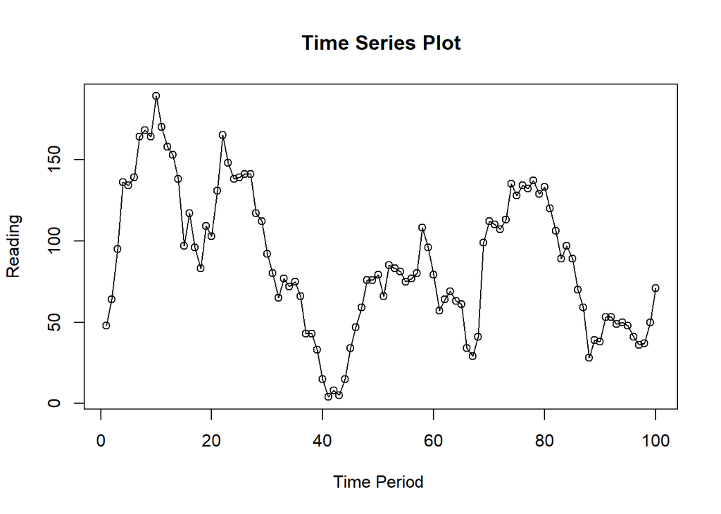

```r
ts.plot(data1.ts, xlab="Time Period ", ylab="Reading",
        main = "Time Series Plot")
points(data1.ts)
```

```r
#menyimpan plot
dev.copy(png, "plot_data1.png")
```

```r
dev.off()
```

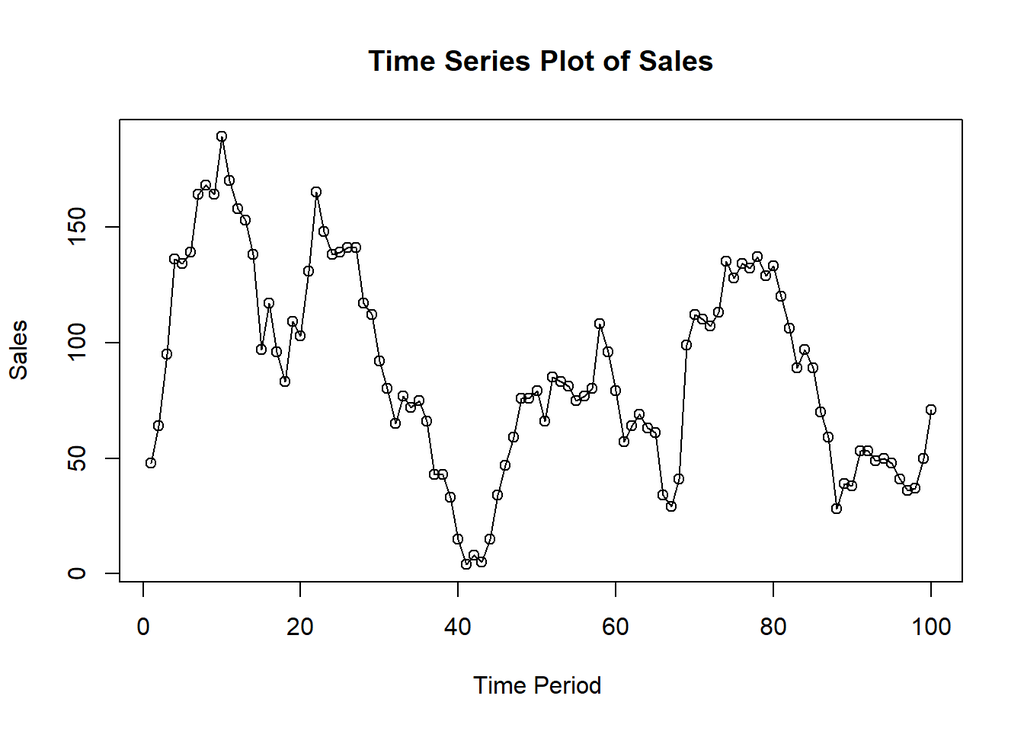

```r
ts.plot(data2.ts, xlab="Time Period ", ylab="Sales",
        main = "Time Series Plot of Sales")
points(data2.ts)
```

```r
#menyimpan plot
dev.copy(png, "plot_data2.png")
```

```r
dev.off()
```

## Single Moving Average & Double Moving Average

### Pembagian Data

Pembagian data latih dan data uji dilakukan dengan perbandingan 80% data latih dan 20% data uji.

```r
# hitung jumlah data
n <- nrow(data2)

# tentukan batas 80%
n_train <- floor(0.8 * n)

# bagi data
training_ma <- data2[1:n_train, ]
testing_ma  <- data2[(n_train+1):n, ]

# ubah ke time series
train_ma.ts <- ts(training_ma$Sales)
test_ma.ts  <- ts(testing_ma$Sales)
```

Eksplorasi data dilakukan pada keseluruhan data, data latih serta data uji menggunakan plot data deret waktu.

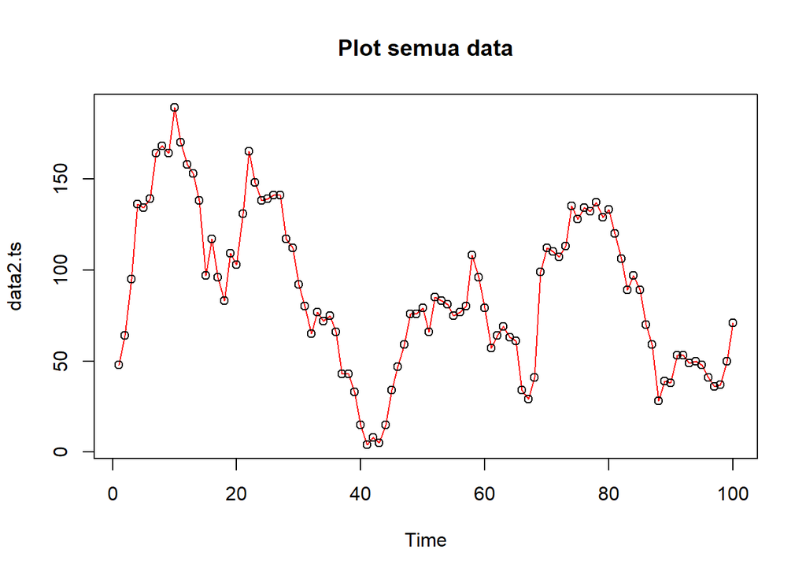

```r
#eksplorasi keseluruhan data
plot(data2.ts, col="red",main="Plot semua data")
points(data2.ts)
```

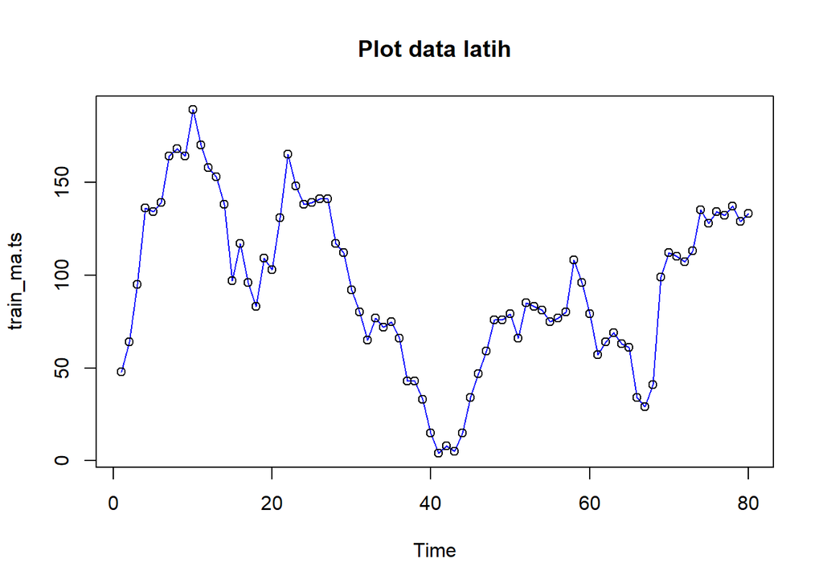

```r
#eksplorasi data latih
plot(train_ma.ts, col="blue",main="Plot data latih")
points(train_ma.ts)
```

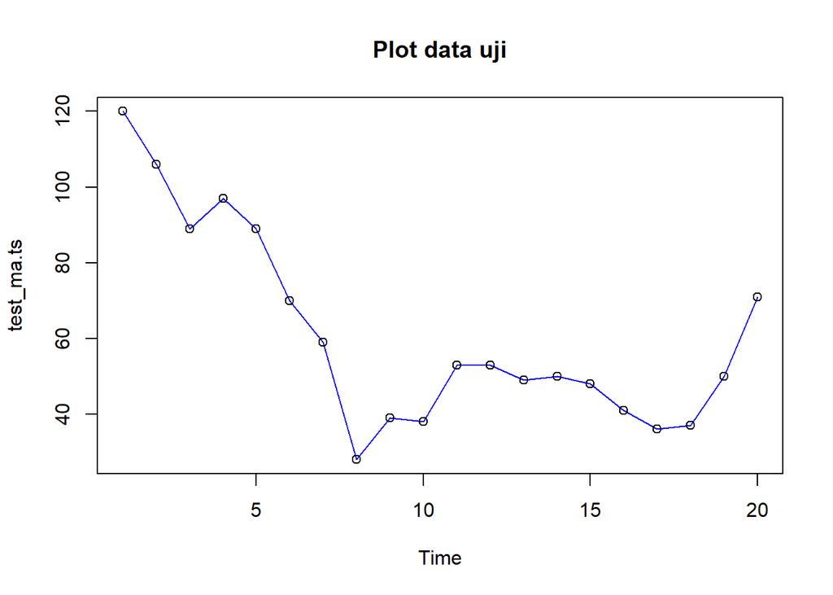

```r
#eksplorasi data uji
plot(test_ma.ts, col="blue",main="Plot data uji")
points(test_ma.ts)
```

Eksplorasi data juga dapat dilakukan menggunakan package `ggplot2` dengan terlebih dahulu memanggil library *package* `ggplot2`.

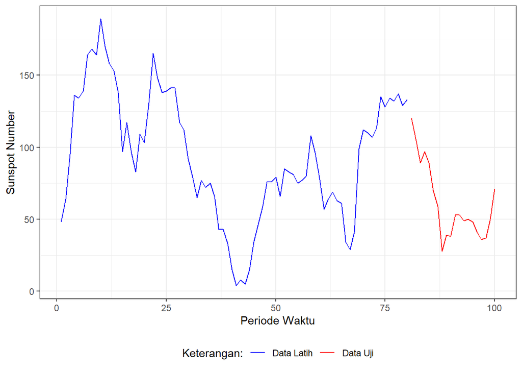

```r
library(ggplot2)
ggplot() +
  geom_line(data = training_ma, aes(x = 1:nrow(training_ma), y = `Sunspot Number`, col = "Data Latih")) +
  geom_line(data = testing_ma, aes(x = (nrow(training_ma) + 1):(nrow(training_ma) + nrow(testing_ma)), y = `Sunspot Number`, col = "Data Uji")) +
  labs(x = "Periode Waktu", y = "Sunspot Number", color = "Legend") +
  scale_colour_manual(name = "Keterangan:", breaks = c("Data Latih", "Data Uji"),
                      values = c("blue", "red")) +
  theme_bw() +
  theme(legend.position = "bottom",
        plot.caption = element_text(hjust = 0.5, size = 12))
```

### Single Moving Average (SMA)

Ide dasar dari Single Moving Average (SMA) adalah data suatu periode dipengaruhi oleh data periode sebelumnya. Metode pemulusan ini cocok digunakan untuk pola data stasioner atau konstan. Prinsip dasar metode pemulusan ini adalah data pemulusan pada periode ke-t merupakan rata rata dari m buah data pada periode ke-t hingga periode ke (t-m+1).

$$S_t = \frac{1}{m} \sum_{i=t-m+1}^{t} X_i$$

Data pemulusan pada periode ke-t selanjutnya digunakan sebagai nilai peramalan pada periode ke t+1.

$$F_t = S_{t-1}, F_{n,h} = S_n$$

Pemulusan menggunakan metode SMA dilakukan dengan fungsi `SMA()`. Dalam hal ini akan dilakukan pemulusan dengan parameter `m=4`.

```r
data.sma<-SMA(train_ma.ts, n=4)
data.sma
```

```
## Time Series:
## Start = 1
## End = 80
## Frequency = 1
##  [1]     NA     NA     NA  85.75 107.25 126.00 143.25 151.25 158.75 171.25
## [11] 172.75 170.25 167.50 154.75 136.50 126.25 112.00  98.25 101.25  97.75
## [21] 106.50 127.00 136.75 145.50 147.50 141.50 139.75 134.50 127.75 115.50
## [31] 100.25  87.25  78.50  73.50  72.25  72.50  64.00  56.75  46.25  33.50
## [41]  23.75  15.00   8.00   8.00  15.50  25.25  38.75  54.00  64.50  72.50
## [51]  74.25  76.50  78.25  78.75  81.00  79.00  78.25  85.00  90.25  90.75
## [61]  85.00  74.00  67.25  63.25  64.25  56.75  46.75  41.25  50.75  70.25
## [71]  90.50 107.00 110.50 116.25 120.75 127.50 132.25 132.75 133.00 132.75
```

Data pemulusan pada periode ke-t selanjutnya digunakan sebagai nilai peramalan pada periode ke t+1 sehingga hasil peramalan 1 periode kedepan adalah sebagai berikut.

```r
data.ramal<-c(NA,data.sma)
data.ramal #forecast 1 periode ke depan
```

```
##  [1]     NA     NA     NA     NA  85.75 107.25 126.00 143.25 151.25 158.75
## [11] 171.25 172.75 170.25 167.50 154.75 136.50 126.25 112.00  98.25 101.25
## [21]  97.75 106.50 127.00 136.75 145.50 147.50 141.50 139.75 134.50 127.75
## [31] 115.50 100.25  87.25  78.50  73.50  72.25  72.50  64.00  56.75  46.25
## [41]  33.50  23.75  15.00   8.00   8.00  15.50  25.25  38.75  54.00  64.50
## [51]  72.50  74.25  76.50  78.25  78.75  81.00  79.00  78.25  85.00  90.25
## [61]  90.75  85.00  74.00  67.25  63.25  64.25  56.75  46.75  41.25  50.75
## [71]  70.25  90.50 107.00 110.50 116.25 120.75 127.50 132.25 132.75 133.00
## [81] 132.75
```

```r
data.gab<-cbind(
  aktual=c(data2.ts),
  pemulusan=c(data.sma,rep(NA,20)),
  ramalan=c(data.ramal,rep(data.ramal[length(data.ramal)],19)))

data.gab #forecast 20 periode ke depan
```

```
##        aktual pemulusan ramalan
##   [1,]     48        NA      NA
##   [2,]     64        NA      NA
##   [3,]     95        NA      NA
##   [4,]    136     85.75      NA
##   [5,]    134    107.25   85.75
##   [6,]    139    126.00  107.25
##   [7,]    164    143.25  126.00
##   [8,]    168    151.25  143.25
##   [9,]    164    158.75  151.25
##  [10,]    189    171.25  158.75
##  [11,]    170    172.75  171.25
##  [12,]    158    170.25  172.75
##  [13,]    153    167.50  170.25
##  [14,]    138    154.75  167.50
```

[output cut: 86 more lines]

Adapun plot data deret waktu dari hasil peramalan yang dilakukan adalah sebagai berikut.

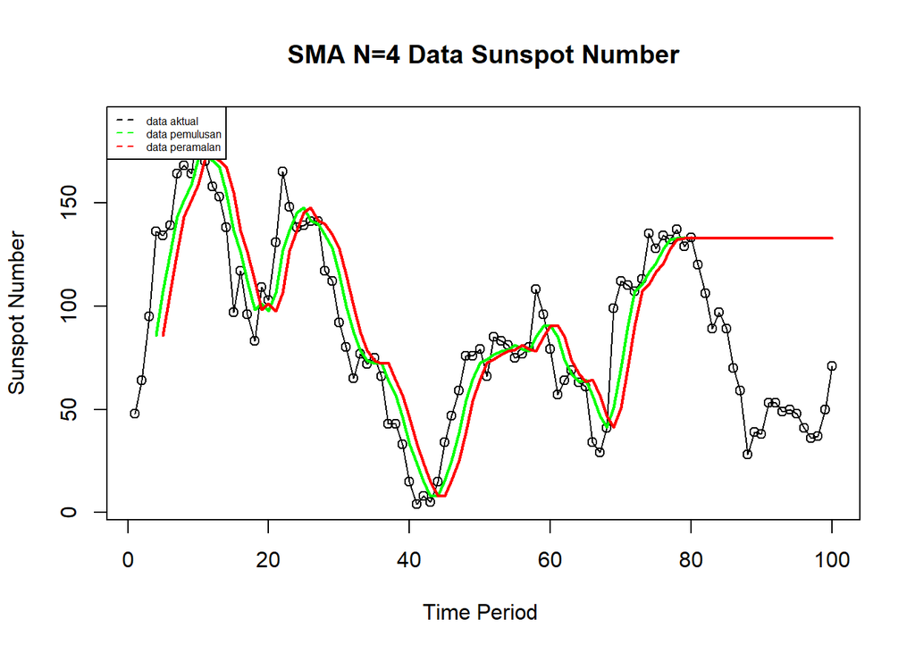

```r
ts.plot(data2.ts, xlab="Time Period ", ylab="Sunspot Number", main= "SMA N=4 Data Sunspot Number")
points(data2.ts)
lines(data.gab[,2],col="green",lwd=2)
lines(data.gab[,3],col="red",lwd=2)
legend("topleft",c("data aktual","data pemulusan","data peramalan"), lty=8, col=c("black","green","red"), cex=0.5)
```

Selanjutnya perhitungan akurasi dilakukan dengan ukuran akurasi *Sum Squares Error* (SSE), *Mean Square Error* (MSE) dan *Mean Absolute Percentage Error* (MAPE). Perhitungan akurasi dilakukan baik pada data latih maupun pada data uji.

$$SSE = \sum_{t=1}^{n} (y_t - \hat{y}_t)^2$$
$$MSE = \frac{1}{n} \sum_{t=1}^{n} (y_t - \hat{y}_t)^2$$
$$MAPE = \frac{1}{n} \sum_{t=1}^{n} \left|\frac{y_t -
\hat{y}_t}{y_t}\right| * 100$$

```r
#Menghitung nilai keakuratan data latih
error_train.sma = train_ma.ts-data.ramal[1:length(train_ma.ts)]

SSE_train.sma = sum(error_train.sma[5:length(train_ma.ts)]^2)
MSE_train.sma = mean(error_train.sma[5:length(train_ma.ts)]^2)
MAPE_train.sma = mean(abs((error_train.sma[5:length(train_ma.ts)]/train_ma.ts[5:length(train_ma.ts)])*100))

akurasi_train.sma <- matrix(c(SSE_train.sma, MSE_train.sma, MAPE_train.sma))
row.names(akurasi_train.sma)<- c("SSE", "MSE", "MAPE")
colnames(akurasi_train.sma) <- c("Akurasi m = 4")
akurasi_train.sma
```

```
##      Akurasi m = 4
## SSE    47167.37500
## MSE      620.62336
## MAPE      40.96489
```

```r
#Menghitung nilai keakuratan data uji
error_test.sma = test_ma.ts-data.gab[81:100,3]

SSE_test.sma = sum(error_test.sma^2)
MSE_test.sma = mean(error_test.sma^2)
MAPE_test.sma = mean(abs((error_test.sma/test_ma.ts*100)))

akurasi_test.sma <- matrix(c(SSE_test.sma, MSE_test.sma, MAPE_test.sma))
row.names(akurasi_test.sma)<- c("SSE", "MSE", "MAPE")
colnames(akurasi_test.sma) <- c("Akurasi m = 4")
akurasi_test.sma
```

```
##      Akurasi m = 4
## SSE    115471.7500
## MSE      5773.5875
## MAPE      153.3609
```

Perhitungan akurasi pada data uji menghasilkan nilai SSE sebesar 115471.75, MSE sebesar 5773.59, dan MAPE sebesar 153.36%. Karena nilai MAPE berada jauh di atas 50%, kemampuan peramalan model Single Moving Average (SMA) m = 4 pada data uji ini dikategorikan buruk (inaccurate). Hal ini menunjukkan bahwa metode SMA kurang mampu menangkap pola perubahan data pada periode pengujian.

### Double Moving Average (DMA)

Metode pemulusan Double Moving Average (DMA) pada dasarnya mirip dengan SMA. Namun demikian, metode ini lebih cocok digunakan untuk pola data trend. Proses pemulusan dengan rata rata dalam metode ini dilakukan sebanyak 2 kali.

- **Tahap I:**

$$S_{1,t} = \frac{1}{m} \sum_{i=t-m+1}^{t} X_i$$

- **Tahap II:**

$$S_{2,t} = \frac{1}{m} \sum_{i=t-m+1}^{t} S_{1,i}$$

Forecast $h$ langkah ke depan dihitung dengan:

$$F_{2,t,t+h} = A_t + B_t \,(h)$$

dengan komponen level ($A_t$) dan tren ($B_t$):

$$A_t = 2S_{1,t} - S_{2,t}
\qquad\text{dan}\qquad
B_t = \frac{2}{m-1}\,\big(S_{1,t} - S_{2,t}\big)$$

```r
dma <- SMA(data.sma, n = 4)
At <- 2*data.sma - dma
Bt <- 2/(4-1)*(data.sma - dma)
data.dma<- At+Bt
data.ramal2<- c(NA, data.dma)

t = 1:20
f = c()

for (i in t) {
  f[i] = At[length(At)] + Bt[length(Bt)]*(i)
}

data.gab2 <- cbind(aktual = c(data2.ts),
                   pemulusan1 = c(data.sma,rep(NA,20)),
pemulusan2 = c(dma, rep(NA,20)),
At = c(At, rep(NA,20)),
Bt = c(Bt,rep(NA,20)),
                   ramalan = c(data.ramal2, f[-1]))
data.gab2
```

```
##        aktual pemulusan1 pemulusan2       At           Bt    ramalan
##   [1,]     48         NA         NA       NA           NA         NA
##   [2,]     64         NA         NA       NA           NA         NA
##   [3,]     95         NA         NA       NA           NA         NA
##   [4,]    136      85.75         NA       NA           NA         NA
##   [5,]    134     107.25         NA       NA           NA         NA
##   [6,]    139     126.00         NA       NA           NA         NA
##   [7,]    164     143.25   115.5625 170.9375  18.45833333         NA
##   [8,]    168     151.25   131.9375 170.5625  12.87500000 189.395833
##   [9,]    164     158.75   144.8125 172.6875   9.29166667 183.437500
##  [10,]    189     171.25   156.1250 186.3750  10.08333333 181.979167
##  [11,]    170     172.75   163.5000 182.0000   6.16666667 196.458333
##  [12,]    158     170.25   168.2500 172.2500   1.33333333 188.166667
##  [13,]    153     167.50   170.4375 164.5625  -1.95833333 173.583333
##  [14,]    138     154.75   166.3125 143.1875  -7.70833333 162.604167
```

[output cut: 86 more lines]

Hasil pemulusan menggunakan metode DMA divisualisasikan sebagai berikut

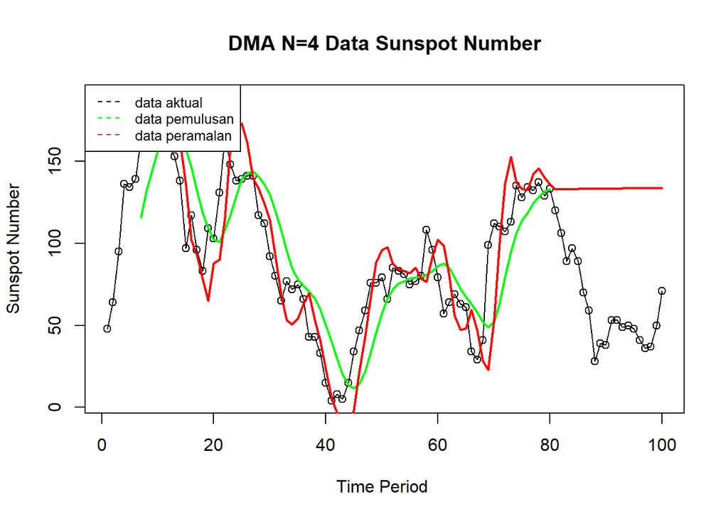

```r
ts.plot(data2.ts, xlab="Time Period ", ylab="Sunspot Number", main= "DMA N=4 Data Sunspot Number")
points(data2.ts)
lines(data.gab2[,3],col="green",lwd=2)
lines(data.gab2[,6],col="red",lwd=2)
legend("topleft",c("data aktual","data pemulusan","data peramalan"), lty=8, col=c("black","green","red"), cex=0.8)
```

Selanjutnya perhitungan akurasi dilakukan baik pada data latih maupun data uji. Perhitungan akurasi dilakukan dengan ukuran akurasi SSE, MSE dan MAPE.

```r
#Menghitung nilai keakuratan data latih
error_train.dma = train_ma.ts-data.ramal2[1:length(train_ma.ts)]

SSE_train.dma = sum(error_train.dma[8:length(train_ma.ts)]^2)
MSE_train.dma = mean(error_train.dma[8:length(train_ma.ts)]^2)
MAPE_train.dma = mean(abs((error_train.dma[8:length(train_ma.ts)]/train_ma.ts[8:length(train_ma.ts)])*100))

akurasi_train.dma <- matrix(c(SSE_train.dma, MSE_train.dma, MAPE_train.dma))
row.names(akurasi_train.dma)<- c("SSE", "MSE", "MAPE")
colnames(akurasi_train.dma) <- c("Akurasi m = 4")
akurasi_train.dma
```

```
##      Akurasi m = 4
## SSE    39804.61979
## MSE      545.26876
## MAPE      30.94693
```

Perhitungan akurasi pada data latih menghasilkan nilai SSE sebesar 39804.62, MSE sebesar 545.27, dan MAPE sebesar 30.95%. Berdasarkan nilai MAPE yang berada di antara 20% hingga 50%, performa pemulusan Double Moving Average (DMA) pada data latih ini masuk dalam kategori cukup/layak (reasonable). Selanjutnya, perhitungan nilai akurasi dilakukan pada data uji.

```r
#Menghitung nilai keakuratan data uji
error_test.dma = test_ma.ts-data.gab2[81:100,6]
SSE_test.dma = sum(error_test.dma^2)
MSE_test.dma = mean(error_test.dma^2)
MAPE_test.dma = mean(abs((error_test.dma/test_ma.ts*100)))

akurasi_test.dma <- matrix(c(SSE_test.dma, MSE_test.dma, MAPE_test.dma))
row.names(akurasi_test.dma)<- c("SSE", "MSE", "MAPE")
colnames(akurasi_test.dma) <- c("Akurasi m = 4")
akurasi_test.dma
```

```
##      Akurasi m = 4
## SSE    117080.0295
## MSE      5854.0015
## MAPE      154.4062
```

Perhitungan akurasi pada data uji menghasilkan nilai SSE sebesar 117080.03, MSE sebesar 5854.00, dan MAPE sebesar 154.41%. Karena nilai MAPE berada jauh di atas 50%, kemampuan peramalan metode Double Moving Average (DMA) pada data uji ini dikategorikan buruk (inaccurate).

Jika dibandingkan antara kedua metode, pada data latih metode DMA menghasilkan nilai error yang lebih kecil (MAPE 30.95%) dibandingkan SMA (MAPE 40.96%). Namun pada data uji, metode SMA memiliki nilai error yang sedikit lebih rendah (MAPE 153.36%) dibandingkan DMA (MAPE 154.41%), meskipun performa kedua metode pada data uji secara umum masih kurang memuaskan.

## Single Exponential Smoothing & Double Exponential Smoothing

Metode Exponential Smoothing merupakan metode pemulusan deret waktu dengan memberikan bobot yang menurun secara eksponensial pada data historis, di mana nilai terbaru mendapat bobot lebih besar dibanding nilai yang lebih lama. Metode ini menggunakan satu atau lebih parameter pemulusan yang secara langsung menentukan besar kecilnya bobot setiap pengamatan. Pemilihan parameter yang tepat akan sangat berpengaruh terhadap hasil ramalan. Secara umum, Exponential Smoothing dibedakan menjadi dua jenis, yaitu model tunggal (single) yang digunakan untuk data tanpa tren maupun musiman, serta model ganda (double) yang mampu menangkap adanya tren pada data.

### Pembagian Data

Pembagian data latih dan data uji dilakukan dengan perbandingan 80% data latih dan 20% data uji.

```r
# jumlah baris data
n <- nrow(data1)

# hitung batas 80%
n_train <- floor(0.8 * n)

# bagi data
training <- data1[1:n_train, ]
testing  <- data1[(n_train+1):n, ]

# ubah ke time series
train.ts <- ts(training$Yt)
test.ts  <- ts(testing$Yt)
```

### Eksplorasi

Eksplorasi dilakukan dengan membuat plot data deret waktu untuk keseluruhan data, data latih, dan data uji.

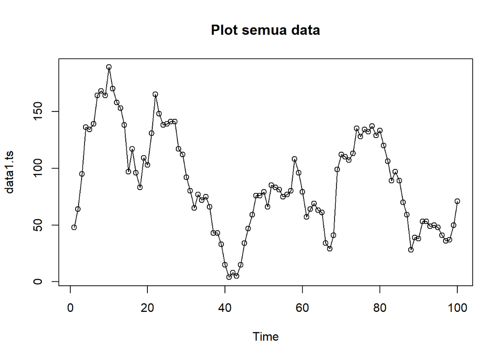

```r
#eksplorasi data
plot(data1.ts, col="black",main="Plot semua data")
points(data1.ts)
```

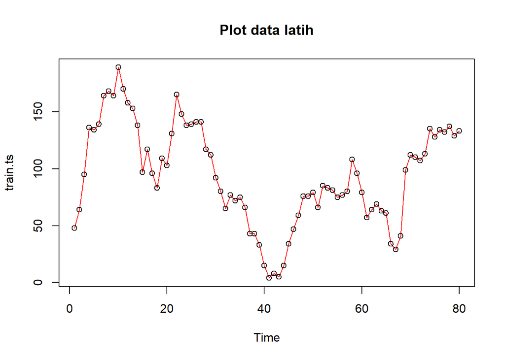

```r
plot(train.ts, col="red",main="Plot data latih")
points(train.ts)
```

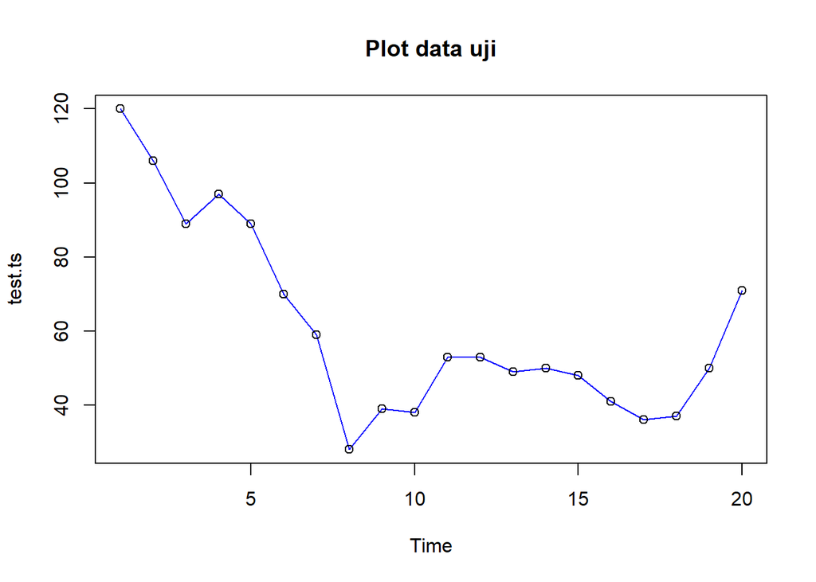

```r
plot(test.ts, col="blue",main="Plot data uji")
points(test.ts)
```

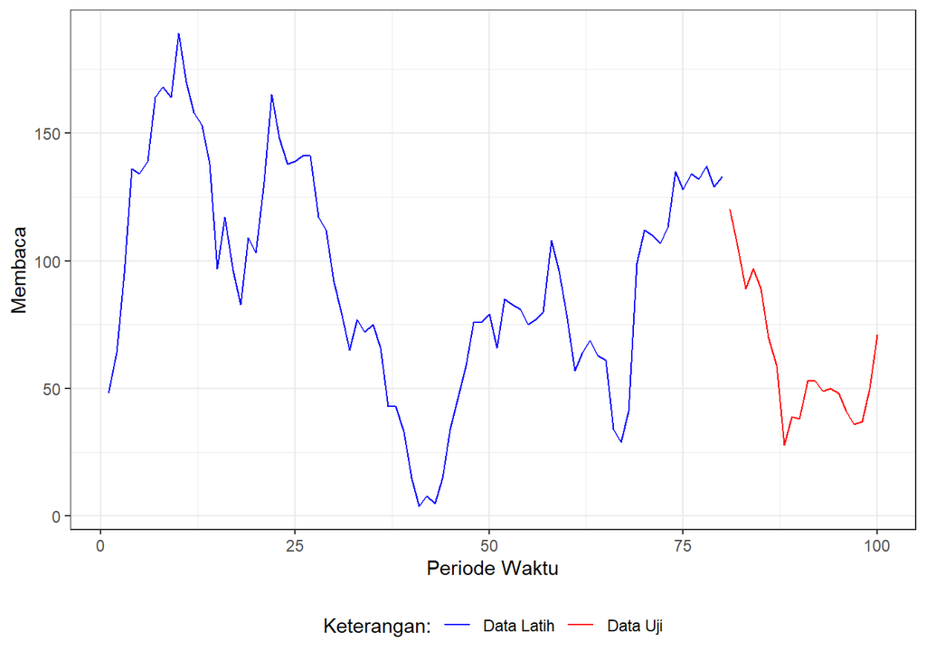

```r
#Eksplorasi dengan GGPLOT
library(ggplot2)
ggplot() +
  geom_line(data = training, aes(x = Periode, y = Yt, col = "Data Latih")) +
  geom_line(data = testing, aes(x = Periode, y = Yt, col = "Data Uji")) +
  labs(x = "Periode Waktu", y = "Membaca", color = "Legend") +
  scale_colour_manual(name="Keterangan:", breaks = c("Data Latih", "Data Uji"),
                      values = c("blue", "red")) +
  theme_bw() + theme(legend.position = "bottom",
                     plot.caption = element_text(hjust=0.5, size=12))
```

## Single Exponential Smoothing

Single Exponential Smoothing (SES) adalah metode peramalan deret waktu yang dikembangkan untuk mengatasi kelemahan Moving Average. Jika pada Moving Average setiap data periode sebelumnya dianggap memiliki bobot yang sama, maka SES memberikan bobot yang semakin mengecil secara eksponensial terhadap data lama, sehingga data terbaru diberi bobot lebih besar.

Single Exponential Smoothing merupakan metode pemulusan yang tepat digunakan untuk data dengan pola stasioner atau konstan.

Nilai pemulusan pada periode ke-t didapat dari persamaan:

$$\tilde{y}_T=\lambda
y_t+(1-\lambda)\tilde{y}_{T-1}$$

Nilai parameter $\lambda$ adalah nilai antara 0 dan 1.

Nilai pemulusan periode ke-t bertindak sebagai nilai ramalan pada periode ke-$(T+\tau)$.

$$\tilde{y}_{T+\tau}(T)=\tilde{y}_T$$

Pemulusan dengan metode SES dapat dilakukan dengan dua fungsi dari *packages* berbeda, yaitu (1) fungsi `ses()` dari *packages* `forecast` dan (2) fungsi `HoltWinters` dari *packages* `stats` .

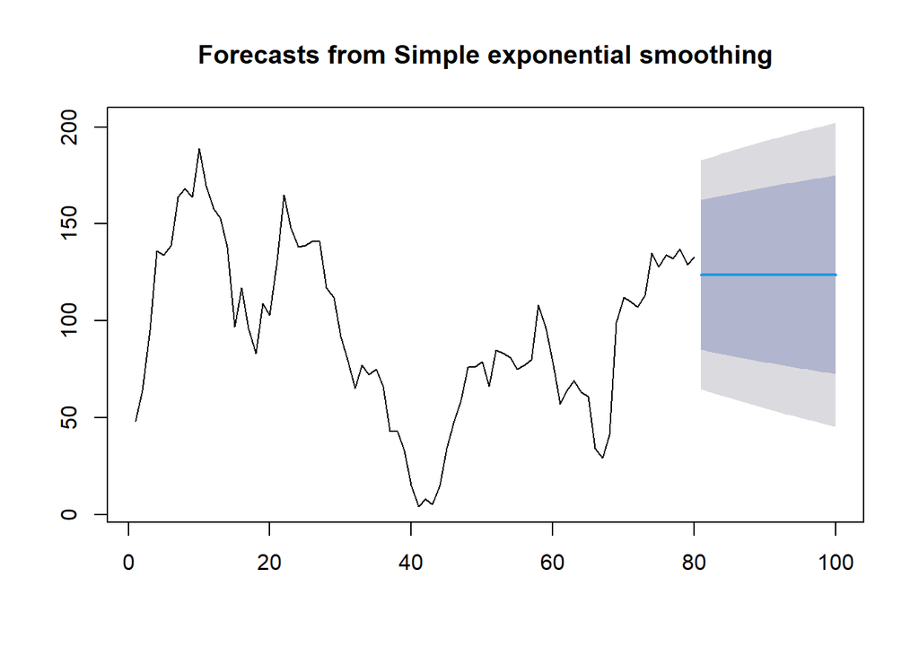

```r
#Cara 1 (fungsi ses)
ses.1 <- ses(train.ts, h = 20, alpha = 0.2)
plot(ses.1)
```

```r
ses.1
```

```
##     Point Forecast    Lo 80    Hi 80    Lo 95    Hi 95
##  81       123.7515 85.09164 162.4113 64.62636 182.8766
##  82       123.7515 84.32602 163.1769 63.45545 184.0475
##  83       123.7515 83.57499 163.9279 62.30686 185.1961
##  84       123.7515 82.83775 164.6652 61.17934 186.3236
##  85       123.7515 82.11356 165.3894 60.07178 187.4311
##  86       123.7515 81.40174 166.1012 58.98316 188.5198
##  87       123.7515 80.70170 166.8012 57.91254 189.5904
##  88       123.7515 80.01286 167.4901 56.85905 190.6439
##  89       123.7515 79.33470 168.1682 55.82189 191.6810
##  90       123.7515 78.66675 168.8362 54.80034 192.7026
##  91       123.7515 78.00854 169.4944 53.79370 193.7092
##  92       123.7515 77.35967 170.1432 52.80134 194.7016
##  93       123.7515 76.71975 170.7832 51.82267 195.6802
##  94       123.7515 76.08843 171.4145 50.85714 196.6458
##  95       123.7515 75.46536 172.0376 49.90424 197.5987
##  96       123.7515 74.85022 172.6527 48.96347 198.5394
##  97       123.7515 74.24273 173.2602 48.03439 199.4685
##  98       123.7515 73.64260 173.8603 47.11657 200.3863
##  99       123.7515 73.04958 174.4533 46.20962 201.2933
## 100       123.7515 72.46341 175.0395 45.31315 202.1898
```

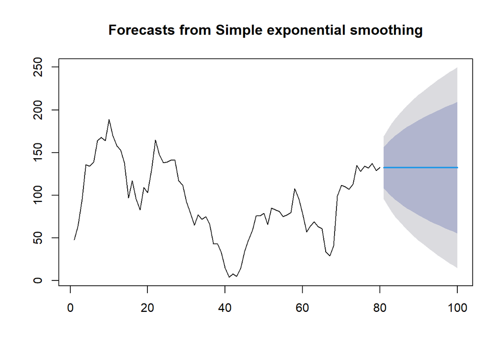

```r
ses.2 <- ses(train.ts, h = 20, alpha = 0.7)
plot(ses.2)
```

```r
ses.2
```

```
##     Point Forecast     Lo 80    Hi 80    Lo 95    Hi 95
##  81       132.3865 108.43114 156.3419 95.74992 169.0231
##  82       132.3865 103.14525 161.6278 87.66585 177.1072
##  83       132.3865  98.67831 166.0948 80.83425 183.9388
##  84       132.3865  94.73768 170.0354 74.80758 189.9655
##  85       132.3865  91.17212 173.6009 69.35452 195.4185
##  86       132.3865  87.89137 176.8817 64.33705 200.4360
##  87       132.3865  84.83644 179.9366 59.66494 205.1081
##  88       132.3865  81.96627 182.8068 55.27539 209.4977
##  89       132.3865  79.25090 185.5222 51.12260 213.6505
##  90       132.3865  76.66771 188.1054 47.17195 217.6011
##  91       132.3865  74.19909 190.5740 43.39651 221.3766
##  92       132.3865  71.83102 192.9421 39.77486 224.9982
##  93       132.3865  69.55213 195.2209 36.28960 228.4835
##  94       132.3865  67.35305 197.4200 32.92640 231.8467
##  95       132.3865  65.22593 199.5471 29.67326 235.0998
##  96       132.3865  63.16415 201.6089 26.52004 238.2530
##  97       132.3865  61.16203 203.6110 23.45806 241.3150
##  98       132.3865  59.21467 205.5584 20.47983 244.2932
##  99       132.3865  57.31781 207.4553 17.57883 247.1942
## 100       132.3865  55.46771 209.3054 14.74935 250.0237
```

Pada fungsi `ses()` , terdapat beberapa argumen yang umum digunakan, yaitu

- `y` : nilai data deret waktu
- `alpha` : parameter pemulusan utama (0–1), mengatur bobot data terbaru vs data lama.
- `beta` : parameter pemulusan tren.
- `gamma` : parameter pemulusan musiman.
- `h` : jumlah periode ke depan yang ingin diramalkan (forecast horizon).

Untuk mendapatkan gambar hasil pemulusan pada data latih dengan fungsi `ses()` , perlu digunakan fungsi `autoplot()` dan `autolayer()` dari *library packages* `ggplot2` .

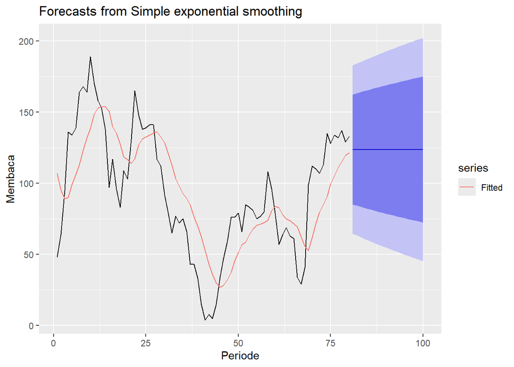

```r
autoplot(ses.1) +
  autolayer(fitted(ses.1), series="Fitted") +
  ylab("Membaca") + xlab("Periode")
```

Selanjutnya akan digunakan fungsi `HoltWinters()` dengan nilai inisialisasi parameter dan panjang periode peramalan yang sama dengan fungsi `ses()` .

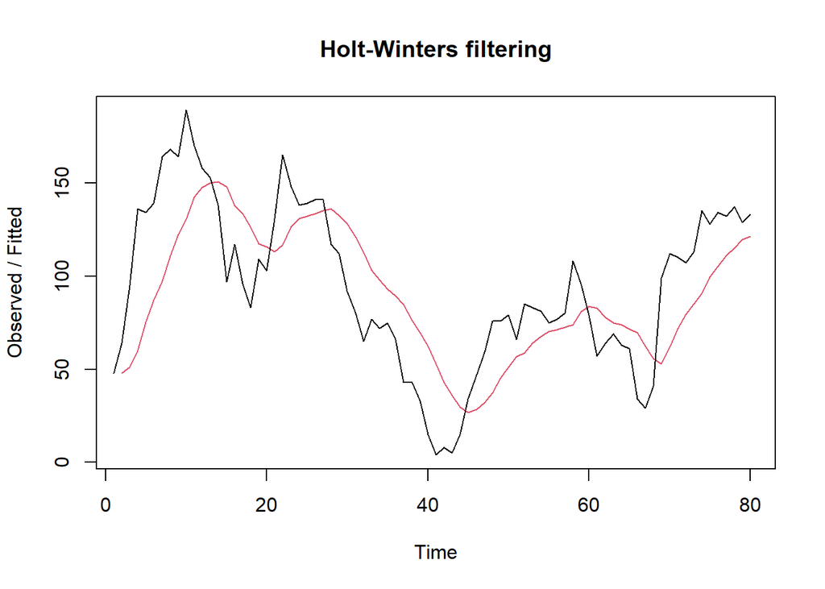

```r
#Cara 2 (fungsi Holtwinter)
ses1<- HoltWinters(train.ts, gamma = FALSE, beta = FALSE, alpha = 0.2)
plot(ses1)
```

```r
#ramalan
ramalan1<- forecast(ses1, h=20)
ramalan1
```

```
##     Point Forecast    Lo 80    Hi 80    Lo 95    Hi 95
##  81       123.7515 83.00758 164.4953 61.43908 186.0638
##  82       123.7515 82.20070 165.3022 60.20505 187.2979
##  83       123.7515 81.40918 166.0937 58.99454 188.5084
##  84       123.7515 80.63220 166.8707 57.80624 189.6967
##  85       123.7515 79.86896 167.6340 56.63897 190.8639
##  86       123.7515 79.11878 168.3841 55.49167 192.0112
##  87       123.7515 78.38100 169.1219 54.36333 193.1396
##  88       123.7515 77.65503 169.8479 53.25305 194.2499
##  89       123.7515 76.94031 170.5626 52.15999 195.3429
##  90       123.7515 76.23634 171.2666 51.08336 196.4196
##  91       123.7515 75.54266 171.9603 50.02246 197.4805
##  92       123.7515 74.85881 172.6441 48.97661 198.5263
##  93       123.7515 74.18440 173.3185 47.94518 199.5577
##  94       123.7515 73.51904 173.9839 46.92760 200.5753
##  95       123.7515 72.86238 174.6405 45.92332 201.5796
##  96       123.7515 72.21408 175.2888 44.93184 202.5711
##  97       123.7515 71.57384 175.9291 43.95268 203.5502
##  98       123.7515 70.94136 176.5616 42.98539 204.5175
##  99       123.7515 70.31637 177.1865 42.02954 205.4734
## 100       123.7515 69.69860 177.8043 41.08475 206.4182
```

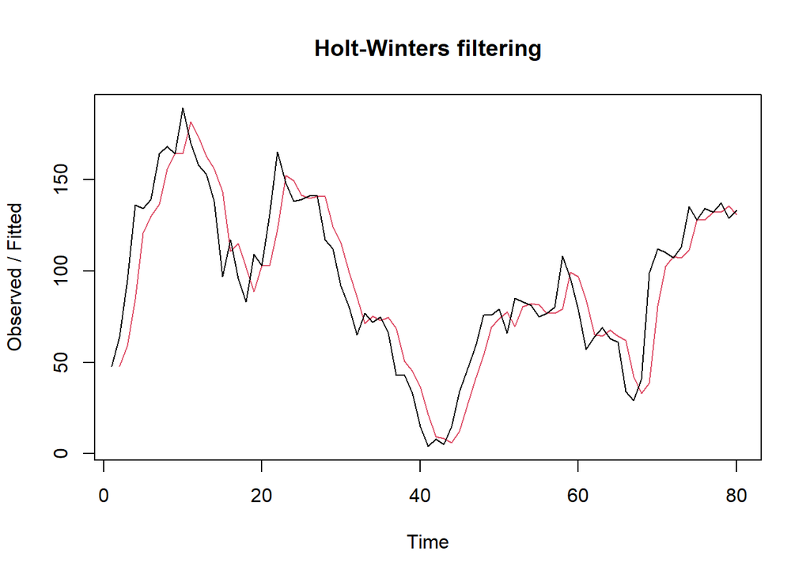

```r
ses2<- HoltWinters(train.ts, gamma = FALSE, beta = FALSE, alpha = 0.7)
plot(ses2)
```

```r
#ramalan
ramalan2<- forecast(ses2, h=20)
ramalan2
```

```
##     Point Forecast     Lo 80    Hi 80    Lo 95    Hi 95
##  81       132.3865 108.47537 156.2977 95.81757 168.9555
##  82       132.3865 103.19924 161.5738 87.74842 177.0246
##  83       132.3865  98.74055 166.0325 80.92944 183.8436
##  84       132.3865  94.80720 169.9659 74.91390 189.8592
##  85       132.3865  91.24822 173.5248 69.47091 195.3022
##  86       132.3865  87.97352 176.7995 64.46270 200.3104
##  87       132.3865  84.92424 179.8488 59.79921 204.9739
##  88       132.3865  82.05936 182.7137 55.41777 209.3553
##  89       132.3865  79.34901 185.4241 51.27265 213.5004
##  90       132.3865  76.77059 188.0025 47.32929 217.4438
##  91       132.3865  74.30653 190.4665 43.56083 221.2122
##  92       132.3865  71.94283 192.8302 39.94586 224.8272
##  93       132.3865  69.66815 195.1049 36.46704 228.3060
##  94       132.3865  67.47313 197.2999 33.11005 231.6630
##  95       132.3865  65.34994 199.4231 29.86291 234.9102
##  96       132.3865  63.29197 201.4811 26.71551 238.0576
##  97       132.3865  61.29354 203.4795 23.65919 241.1139
##  98       132.3865  59.34978 205.4233 20.68645 244.0866
##  99       132.3865  57.45642 207.3166 17.79081 246.9823
## 100       132.3865  55.60974 209.1633 14.96656 249.8065
```

Fungsi `HoltWinters` memiliki argumen yang sama dengan fungsi `ses()` . Argumen-argumen kedua fungsi dapat dilihat lebih lanjut dengan `?ses()` atau `?HoltWinters` .

Nilai parameter $\alpha$ dari kedua fungsi dapat dioptimalkan menyesuaikan dari *error*-nya paling minimumnya. Caranya adalah dengan membuat parameter $\alpha =$ `NULL` .

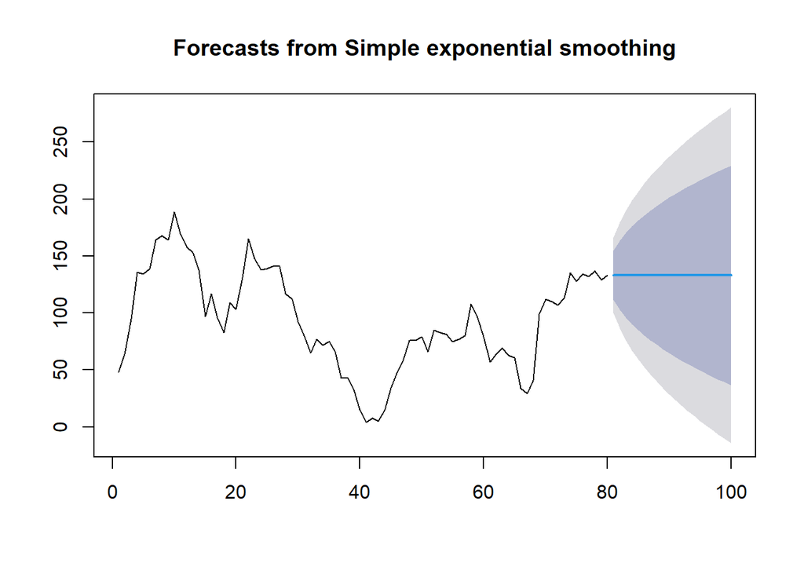

```r
#SES
ses.opt <- ses(train.ts, h = 20, alpha = NULL)
plot(ses.opt)
```

```r
ses.opt
```

```
##     Point Forecast     Lo 80    Hi 80      Lo 95    Hi 95
##  81       132.9996 111.44651 154.5527 100.036999 165.9622
##  82       132.9996 102.52046 163.4787  86.385774 179.6134
##  83       132.9996  95.67105 170.3282  75.910507 190.0887
##  84       132.9996  89.89666 176.1025  67.079344 198.9199
##  85       132.9996  84.80929 181.1899  59.298881 206.7003
##  86       132.9996  80.20994 185.7893  52.264777 213.7344
##  87       132.9996  75.98038 190.0188  45.796232 220.2030
##  88       132.9996  72.04360 193.9556  39.775445 226.2238
##  89       132.9996  68.34609 197.6531  34.120589 231.8786
##  90       132.9996  64.84889 201.1503  28.772087 237.2271
##  91       132.9996  61.52260 204.4766  23.684962 242.3142
##  92       132.9996  58.34436 207.6548  18.824271 247.1749
##  93       132.9996  55.29602 210.7032  14.162226 251.8370
##  94       132.9996  52.36283 213.6364   9.676296 256.3229
##  95       132.9996  49.53265 216.4666   5.347914 260.6513
##  96       132.9996  46.79534 219.2039   1.161560 264.8376
##  97       132.9996  44.14231 221.8569  -2.895891 268.8951
##  98       132.9996  41.56624 224.4330  -6.835661 272.8349
##  99       132.9996  39.06078 226.9384 -10.667431 276.6666
## 100       132.9996  36.62043 229.3788 -14.399625 280.3988
```

```r
#Lamda Optimum Holt Winter
HWopt<- HoltWinters(train.ts, gamma = FALSE, beta = FALSE,alpha = NULL)
HWopt
```

```
## Holt-Winters exponential smoothing without trend and without seasonal component.
##
## Call:
## HoltWinters(x = train.ts, alpha = NULL, beta = FALSE, gamma = FALSE)
##
## Smoothing parameters:
##  alpha: 0.9999319
##  beta : FALSE
##  gamma: FALSE
##
## Coefficients:
##       [,1]
## a 132.9997
```

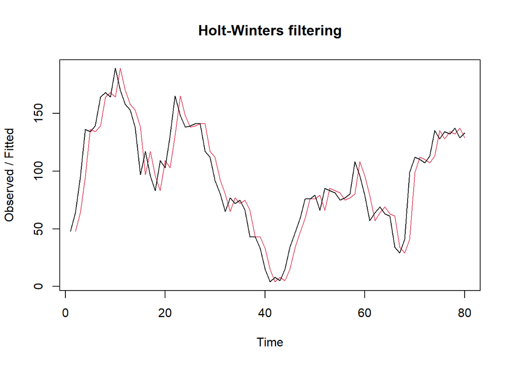

```r
plot(HWopt)
```

```r
#ramalan
ramalanopt<- forecast(HWopt, h=20)
ramalanopt
```

```
##     Point Forecast     Lo 80    Hi 80      Lo 95    Hi 95
##  81       132.9997 111.49150 154.5080 100.105725 165.8937
##  82       132.9997 102.58353 163.4159  86.482167 179.5173
##  83       132.9997  95.74807 170.2514  76.028230 189.9712
##  84       132.9997  89.98546 176.0140  67.215082 198.7844
##  85       132.9997  84.90848 181.0910  59.450508 206.5489
##  86       132.9997  80.31852 185.6809  52.430777 213.5687
##  87       132.9997  76.09761 189.9018  45.975456 220.0240
##  88       132.9997  72.16888 193.8306  39.966981 226.0325
##  89       132.9997  68.47894 197.5205  34.323692 231.6758
##  90       132.9997  64.98889 201.0106  28.986132 237.0133
##  91       132.9997  61.66941 204.3300  23.909416 242.0900
##  92       132.9997  58.49768 207.5018  19.058672 246.9408
##  93       132.9997  55.45557 210.5439  14.406168 251.5933
##  94       132.9997  52.52838 213.4711   9.929421 256.0700
##  95       132.9997  49.70400 216.2955   5.609899 260.3896
##  96       132.9997  46.97229 219.0272   1.432116 264.5673
##  97       132.9997  44.32470 221.6748  -2.617029 268.6165
##  98       132.9997  41.75389 224.2456  -6.548732 272.5482
##  99       132.9997  39.25356 226.7459 -10.372657 276.3721
## 100       132.9997  36.81821 229.1812 -14.097209 280.0967
```

Setelah dilakukan peramalan, akan dilakukan perhitungan keakuratan hasil peramalan. Perhitungan akurasi ini dilakukan baik pada data latih dan data uji.

#### Akurasi Data Latih

Perhitungan akurasi data dapat dilakukan dengan cara langsung maupun manual. Secara langsung, nilai akurasi dapat diambil dari objek yang tersimpan pada hasil SES, yaitu *sum of squared errors* (SSE). Nilai akurasi lain dapat dihitung pula dari nilai SSE tersebut.

```r
#Keakuratan Metode
#Pada data training

# SES dengan alpha = 0.2
SSE1<-ses1$SSE
MSE1<-ses1$SSE/length(train.ts)
RMSE1<-sqrt(MSE1)

akurasi1 <- matrix(c(SSE1,MSE1,RMSE1))
row.names(akurasi1)<- c("SSE", "MSE", "RMSE")
colnames(akurasi1) <- c("Akurasi lamda=0.2")
akurasi1
```

```
##      Akurasi lamda=0.2
## SSE        80655.99321
## MSE         1008.19992
## RMSE          31.75216
```

```r
# SES dengan alpha = 0.7
SSE2<-ses2$SSE
MSE2<-ses2$SSE/length(train.ts)
RMSE2<-sqrt(MSE2)

akurasi2 <- matrix(c(SSE2,MSE2,RMSE2))
row.names(akurasi2)<- c("SSE", "MSE", "RMSE")
colnames(akurasi2) <- c("Akurasi lamda=0.7")
akurasi2
```

```
##      Akurasi lamda=0.7
## SSE        27337.32995
## MSE          341.71662
## RMSE          18.48558
```

```r
#Cara Manual
# Alpha = 0.2
fitted1<-ramalan1$fitted
sisaan1<-ramalan1$residuals
head(sisaan1)
```

```
## Time Series:
## Start = 1
## End = 6
## Frequency = 1
## [1]      NA 16.0000 43.8000 76.0400 58.8320 52.0656
```

```r
resid1<-training$Yt-ramalan1$fitted
head(resid1)
```

```
## Time Series:
## Start = 1
## End = 6
## Frequency = 1
## [1]      NA 16.0000 43.8000 76.0400 58.8320 52.0656
```

```r
SSE.1=sum(sisaan1[2:length(train.ts)]^2)
SSE.1
```

```
## [1] 80655.99
```

```r
MSE.1 = SSE.1/length(train.ts)
MSE.1
```

```
## [1] 1008.2
```

```r
MAPE.1 = sum(abs(sisaan1[2:length(train.ts)]/train.ts[2:length(train.ts)])*
               100)/length(train.ts)
MAPE.1
```

```
## [1] 62.49321
```

```r
akurasi.1 <- matrix(c(SSE.1,MSE.1,MAPE.1))
row.names(akurasi.1)<- c("SSE", "MSE", "MAPE")
colnames(akurasi.1) <- c("Akurasi lamda=0.2")
akurasi.1
```

```
##      Akurasi lamda=0.2
## SSE        80655.99321
## MSE         1008.19992
## MAPE          62.49321
```

```r
# Alpha = 0.7
fitted2<-ramalan2$fitted
sisaan2<-ramalan2$residuals
head(sisaan2)
```

```
## Time Series:
## Start = 1
## End = 6
## Frequency = 1
## [1]      NA 16.0000 35.8000 51.7400 13.5220  9.0566
```

```r
resid2<-training$Yt-ramalan2$fitted
head(resid2)
```

```
## Time Series:
## Start = 1
## End = 6
## Frequency = 1
## [1]      NA 16.0000 35.8000 51.7400 13.5220  9.0566
```

```r
SSE.2=sum(sisaan2[2:length(train.ts)]^2)
SSE.2
```

```
## [1] 27337.33
```

```r
MSE.2 = SSE.2/length(train.ts)
MSE.2
```

```
## [1] 341.7166
```

```r
MAPE.2 = sum(abs(sisaan2[2:length(train.ts)]/train.ts[2:length(train.ts)])*
               100)/length(train.ts)
MAPE.2
```

```
## [1] 24.79456
```

```r
akurasi.2 <- matrix(c(SSE.2,MSE.2,MAPE.2))
row.names(akurasi.2)<- c("SSE", "MSE", "MAPE")
colnames(akurasi.2) <- c("Akurasi lamda=0.7")
akurasi.2
```

```
##      Akurasi lamda=0.7
## SSE        27337.32995
## MSE          341.71662
## MAPE          24.79456
```

#### Akurasi Data Uji

Akurasi data uji dapat dihitung dengan cara yang hampir sama dengan perhitungan akurasi data latih.

```r
# jumlah observasi uji
n_test <- nrow(testing)

# error (ramalan - aktual), samakan panjang dan tipe numeric
e1   <- as.numeric(ramalan1$mean)[1:n_test] - as.numeric(testing$Yt)
e2   <- as.numeric(ramalan2$mean)[1:n_test] - as.numeric(testing$Yt)
eopt <- as.numeric(ramalanopt$mean)[1:n_test] - as.numeric(testing$Yt)

# SSE / MSE / RMSE untuk masing-masing model (abaikan NA)
SSEtesting1  <- sum(e1^2,  na.rm = TRUE)
MSEtesting1  <- mean(e1^2, na.rm = TRUE)
RMSEtesting1 <- sqrt(MSEtesting1)

SSEtesting2  <- sum(e2^2,  na.rm = TRUE)
MSEtesting2  <- mean(e2^2, na.rm = TRUE)
RMSEtesting2 <- sqrt(MSEtesting2)

SSEtestingopt  <- sum(eopt^2,  na.rm = TRUE)
MSEtestingopt  <- mean(eopt^2, na.rm = TRUE)
RMSEtestingopt <- sqrt(MSEtestingopt)

# Tabel ringkas
akurasitesting_SSE <- matrix(c(SSEtesting1, SSEtesting2, SSEtestingopt),
                             nrow = 3,
                             dimnames = list(c("SSE1","SSE2","SSEopt"), "Nilai"))
akurasitesting_MSE <- matrix(c(MSEtesting1, MSEtesting2, MSEtestingopt),
                             nrow = 3,
                             dimnames = list(c("MSE1","MSE2","MSEopt"), "Nilai"))
akurasitesting_RMSE <- matrix(c(RMSEtesting1, RMSEtesting2, RMSEtestingopt),
                              nrow = 3,
                              dimnames = list(c("RMSE1","RMSE2","RMSEopt"), "Nilai"))

akurasitesting_SSE
```

```
##           Nilai
## SSE1    91319.4
## SSE2   114433.4
## SSEopt 116188.2
```

```r
akurasitesting_MSE
```

```
##           Nilai
## MSE1   4565.970
## MSE2   5721.671
## MSEopt 5809.411
```

```r
akurasitesting_RMSE
```

```
##            Nilai
## RMSE1   67.57196
## RMSE2   75.64173
## RMSEopt 76.21949
```

Selain dengan cara di atas, perhitungan nilai akurasi dapat menggunakan fungsi `accuracy()` dari *package* `forecast` . Penggunaannya yaitu dengan menuliskan `accuracy(hasil ramalan, kondisi aktual)` . Contohnya adalah sebagai berikut.

```r
accuracy(ramalan1, testing$Yt)
```

```
##                      ME     RMSE      MAE        MPE      MAPE     MASE
## Training set   4.794396 31.95250 27.28005  -34.69292  63.28427 2.161609
## Test set     -62.601458 67.57196 62.60146 -136.18668 136.18668 4.960396
##                   ACF1
## Training set 0.8513949
## Test set            NA
```

```r
accuracy(ramalan2, testing$Yt)
```

```
##                      ME     RMSE      MAE         MPE      MAPE    MASE
## Training set   1.525977 18.60221 13.76529   -7.803461  25.10841 1.09073
## Test set     -71.236534 75.64173 71.23653 -152.667215 152.66721 5.64462
##                   ACF1
## Training set 0.4690064
## Test set            NA
```

```r
accuracy(ramalanopt, testing$Yt)
```

```
##                      ME     RMSE      MAE         MPE      MAPE     MASE
## Training set   1.076019 16.71108 12.62034   -4.294464  21.47423 1.000007
## Test set     -71.849728 76.21949 71.84973 -153.837530 153.83753 5.693208
##                   ACF1
## Training set 0.1837266
## Test set            NA
```

## *Double Exponential Smoothing* (DES)

Metode pemulusan *Double Exponential Smoothing* (DES) digunakan untuk data yang memiliki pola tren. Metode DES adalah metode semacam SES, hanya saja dilakukan dua kali, yaitu pertama untuk tahapan ‘level’ dan kedua untuk tahapan ‘tren’. Pemulusan menggunakan metode ini akan menghasilkan peramalan tidak konstan untuk periode berikutnya.

Pemulusan dengan metode DES kali ini akan menggunakan fungsi `HoltWinters()` . Jika sebelumnya nilai argumen `beta` dibuat `FALSE` , kali ini argumen tersebut akan diinisialisasi bersamaan dengan nilai `alpha` .

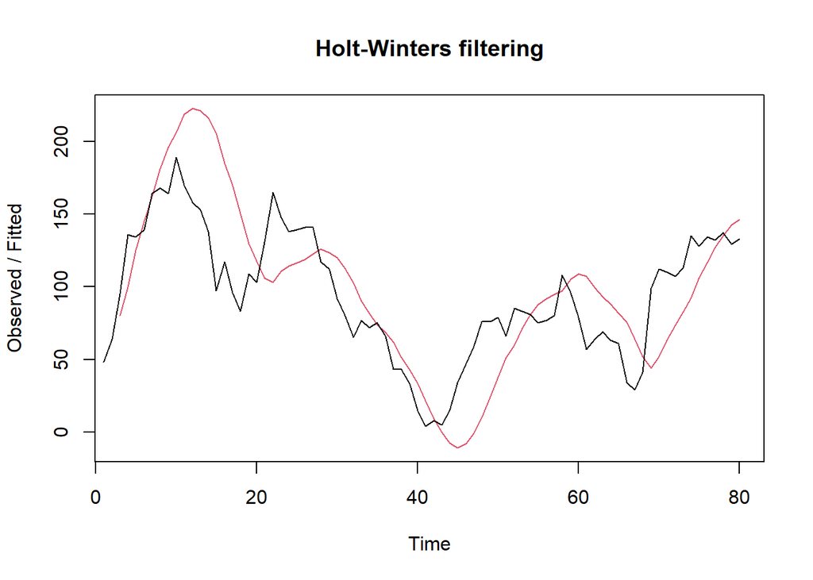

```r
#Lamda=0.2 dan gamma=0.2
des.1<- HoltWinters(train.ts, gamma = FALSE, beta = 0.2, alpha = 0.2)
plot(des.1)
```

```r
#ramalan
ramalandes1<- forecast(des.1, h=20)
ramalandes1
```

```
##     Point Forecast    Lo 80    Hi 80    Lo 95    Hi 95
##  81       149.8243 103.1121 196.5366 78.38411 221.2645
##  82       155.8899 107.8511 203.9286 82.42097 229.3587
##  83       161.9554 112.1679 211.7428 85.81206 238.0987
##  84       168.0209 116.0380 220.0039 88.51982 247.5220
##  85       174.0865 119.4511 228.7218 90.52891 257.6440
##  86       180.1520 122.4099 237.8941 91.84313 268.4609
##  87       186.2175 124.9265 247.5086 92.48103 279.9541
##  88       192.2831 127.0195 257.5466 92.47112 292.0951
##  89       198.3486 128.7113 267.9859 91.84759 304.8497
##  90       204.4142 130.0257 278.8026 90.64690 318.1814
##  91       210.4797 130.9865 289.9729 88.90535 332.0541
##  92       216.5452 131.6163 301.4742 86.65759 346.4329
##  93       222.6108 131.9361 313.2855 83.93579 361.2858
##  94       228.6763 131.9651 325.3876 80.76921 376.5834
##  95       234.7419 131.7204 337.7633 77.18421 392.2995
##  96       240.8074 131.2177 350.3971 73.20435 408.4104
##  97       246.8729 130.4704 363.2755 68.85059 424.8953
##  98       252.9385 129.4908 376.3861 64.14159 441.7354
##  99       259.0040 128.2898 389.7182 59.09394 458.9141
## 100       265.0696 126.8771 403.2620 53.72242 476.4167
```

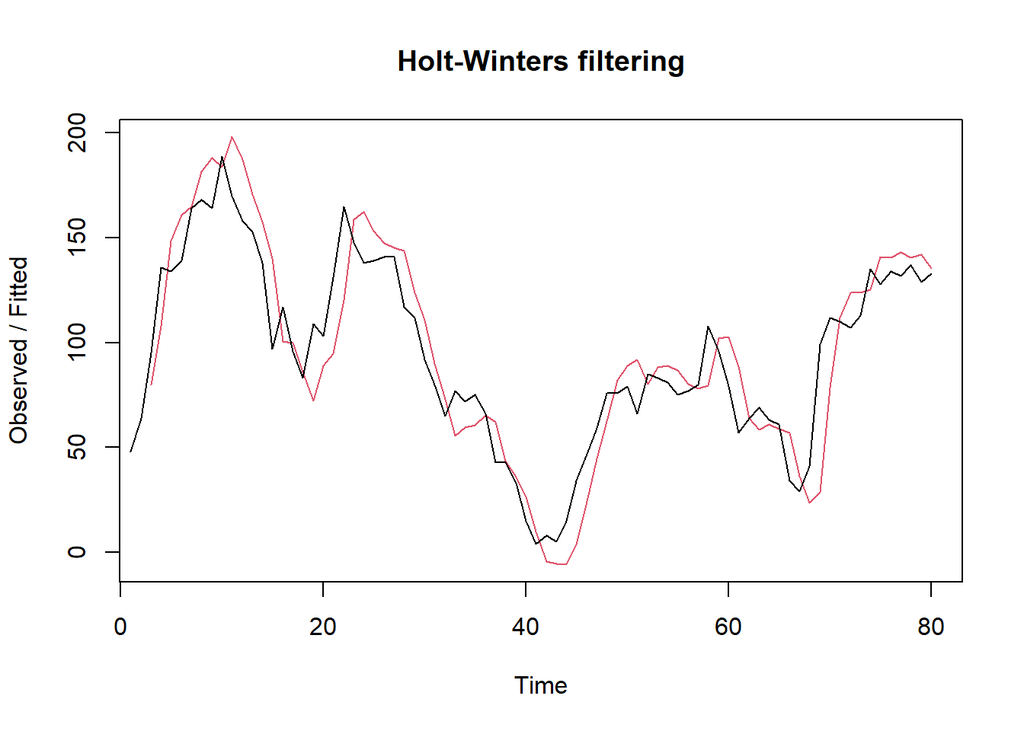

```r
#Lamda=0.6 dan gamma=0.3
des.2<- HoltWinters(train.ts, gamma = FALSE, beta = 0.3, alpha = 0.6)
plot(des.2)
```

```r
#ramalan
ramalandes2<- forecast(des.2, h=20)
ramalandes2
```

```
##     Point Forecast       Lo 80    Hi 80       Lo 95    Hi 95
##  81       134.8424  109.719749 159.9651   96.420620 173.2642
##  82       135.6705  103.809278 167.5317   86.942963 184.3981
##  83       136.4986   96.538589 176.4586   75.385030 197.6122
##  84       137.3267   88.163288 186.4902   62.137739 212.5157
##  85       138.1548   78.852594 197.4571   47.459889 228.8498
##  86       138.9829   68.720304 209.2456   31.525516 246.4403
##  87       139.8110   57.846485 221.7756   14.457071 265.1650
##  88       140.6391   46.290289 234.9880   -3.654977 284.9333
##  89       141.4672   34.097374 248.8371  -22.740805 305.6753
##  90       142.2954   21.304289 263.2864  -42.744513 327.3352
##  91       143.1235    7.941183 278.3057  -63.619993 349.8669
##  92       143.9516   -5.966475 293.8696  -85.328294 373.2314
##  93       144.7797  -20.396747 309.9561 -107.835862 397.3952
##  94       145.6078  -35.330435 326.5460 -131.113340 422.3289
##  95       146.4359  -50.750526 343.6223 -155.134707 448.0065
##  96       147.2640  -66.641779 361.1698 -179.876654 474.4046
##  97       148.0921  -82.990417 379.1746 -205.318112 501.5023
##  98       148.9202  -99.783897 397.6243 -231.439897 529.2803
##  99       149.7483 -117.010721 416.5073 -258.224422 557.7210
## 100       150.5764 -134.660290 435.8131 -285.655482 586.8083
```

Selanjutnya jika ingin membandingkan plot data latih dan data uji adalah sebagai berikut.

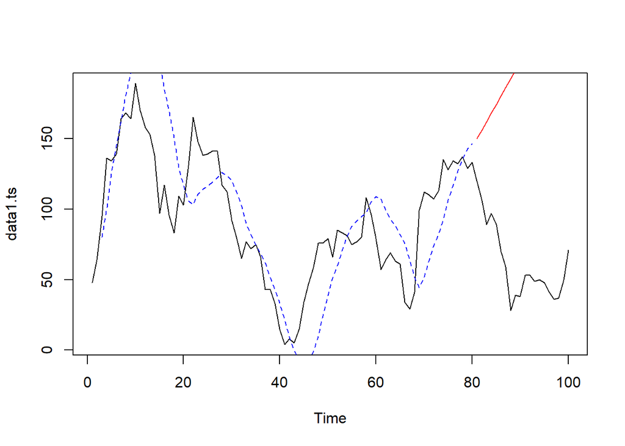

```r
plot(data1.ts)
lines(des.1$fitted[,1], lty=2, col="blue")
lines(ramalandes1$mean, col="red")
```

Untuk mendapatkan nilai parameter optimum dari DES, argumen `alpha` dan `beta` dapat dibuat `NULL` seperti berikut.

```r
#Lamda dan gamma optimum
des.opt<- HoltWinters(train.ts, gamma = FALSE)
des.opt
```

```
## Holt-Winters exponential smoothing with trend and without seasonal component.
##
## Call:
## HoltWinters(x = train.ts, gamma = FALSE)
##
## Smoothing parameters:
##  alpha: 1
##  beta : 0.1536957
##  gamma: FALSE
##
## Coefficients:
##        [,1]
## a 133.00000
## b   2.70525
```

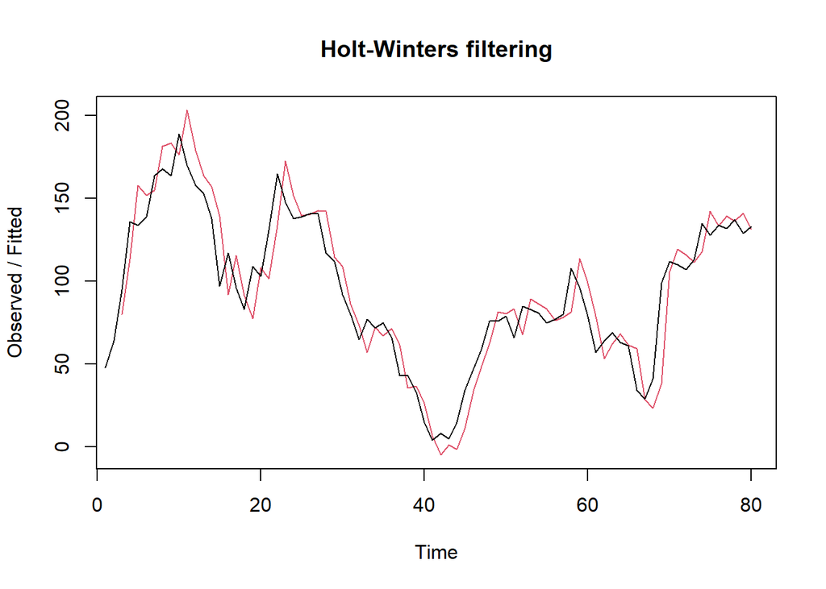

```r
plot(des.opt)
```

```r
#ramalan
ramalandesopt<- forecast(des.opt, h=20)
ramalandesopt
```

```
##     Point Forecast      Lo 80    Hi 80       Lo 95    Hi 95
##  81       135.7052 113.678097 157.7324  102.017627 169.3929
##  82       138.4105 104.780196 172.0408   86.977389 189.8436
##  83       141.1157  96.840152 185.3913   73.402067 208.8294
##  84       143.8210  89.084248 198.5578   60.108362 227.5336
##  85       146.5262  81.247840 211.8047   46.691538 246.3610
##  86       149.2315  73.213557 225.2494   32.972089 265.4909
##  87       151.9367  64.922926 238.9506   18.860590 285.0129
##  88       154.6420  56.345369 252.9386    4.310277 304.9737
##  89       157.3472  47.464965 267.2295  -10.703202 325.3977
##  90       160.0525  38.274031 281.8310  -26.191595 346.2966
##  91       162.7577  28.769738 296.7458  -42.159229 367.6747
##  92       165.4630  18.952199 311.9738  -58.605932 389.5319
##  93       168.1682   8.823338 327.5132  -75.528761 411.8653
##  94       170.8735  -1.613801 343.3608  -92.923060 434.6701
##  95       173.5787 -12.355489 359.5130 -110.783128 457.9406
##  96       176.2840 -23.397600 375.9656 -129.102652 481.6706
##  97       178.9892 -34.735788 392.7143 -147.874987 505.8535
##  98       181.6945 -46.365614 409.7546 -167.093344 530.4823
##  99       184.3997 -58.282627 427.0821 -186.750914 555.5504
## 100       187.1050 -70.482413 444.6924 -206.840951 581.0509
```

Selanjutnya akan dilakukan perhitungan akurasi pada data latih maupun data uji dengan ukuran akurasi SSE, MSE dan MAPE.

#### Akurasi Data Latih

```r
#Akurasi Data Training
ssedes.train1<-des.1$SSE
msedes.train1<-ssedes.train1/length(train.ts)
sisaandes1<-ramalandes1$residuals
head(sisaandes1)
```

```
## Time Series:
## Start = 1
## End = 6
## Frequency = 1
## [1]       NA       NA 15.00000 36.40000  9.06400 -6.16736
```

```r
mapedes.train1 <- sum(abs(sisaandes1[3:length(train.ts)]/train.ts[3:length(train.ts)])
                      *100)/length(train.ts)

akurasides.1 <- matrix(c(ssedes.train1,msedes.train1,mapedes.train1))
row.names(akurasides.1)<- c("SSE", "MSE", "MAPE")
colnames(akurasides.1) <- c("Akurasi lamda=0.2 dan gamma=0.2")
akurasides.1
```

```
##      Akurasi lamda=0.2 dan gamma=0.2
## SSE                     103091.82793
## MSE                       1288.64785
## MAPE                        42.82138
```

```r
ssedes.train2<-des.2$SSE
msedes.train2<-ssedes.train2/length(train.ts)
sisaandes2<-ramalandes2$residuals
head(sisaandes2)
```

```
## Time Series:
## Start = 1
## End = 6
## Frequency = 1
## [1]        NA        NA  15.00000  28.30000 -14.47400 -21.97828
```

```r
mapedes.train2 <- sum(abs(sisaandes2[3:length(train.ts)]/train.ts[3:length(train.ts)])
                      *100)/length(train.ts)

akurasides.2 <- matrix(c(ssedes.train2,msedes.train2,mapedes.train2))
row.names(akurasides.2)<- c("SSE", "MSE", "MAPE")
colnames(akurasides.2) <- c("Akurasi lamda=0.6 dan gamma=0.3")
akurasides.2
```

```
##      Akurasi lamda=0.6 dan gamma=0.3
## SSE                      29681.39345
## MSE                        371.01742
## MAPE                        25.23483
```

#### Akurasi Data Uji

```r
#Akurasi Data Testing
selisihdes1<-ramalandes1$mean-testing$Yt
selisihdes1
```

```
## Time Series:
## Start = 81
## End = 100
## Frequency = 1
##  [1]  29.82431  49.88985  72.95539  71.02093  85.08647 110.15201 127.21755
##  [8] 164.28309 159.34862 166.41416 157.47970 163.54524 173.61078 178.67632
## [15] 186.74186 199.80740 210.87293 215.93847 209.00401 194.06955
```

```r
SSEtestingdes1<-sum(selisihdes1^2)
MSEtestingdes1<-SSEtestingdes1/length(testing$Yt)
MAPEtestingdes1<-sum(abs(selisihdes1/testing$Yt)*100)/length(testing$Yt)

selisihdes2<-ramalandes2$mean-testing$Yt
selisihdes2
```

```
## Time Series:
## Start = 81
## End = 100
## Frequency = 1
##  [1]  14.84240  29.67051  47.49861  40.32672  49.15483  68.98293  80.81104
##  [8] 112.63914 102.46725 104.29536  90.12346  90.95157  95.77967  95.60778
## [15]  98.43589 106.26399 112.09210 111.92020  99.74831  79.57642
```

```r
SSEtestingdes2<-sum(selisihdes2^2)
MSEtestingdes2<-SSEtestingdes2/length(testing$Yt)
MAPEtestingdes2<-sum(abs(selisihdes2/testing$Yt)*100)/length(testing$Yt)

selisihdesopt<-ramalandesopt$mean-testing$Yt
selisihdesopt
```

```
## Time Series:
## Start = 81
## End = 100
## Frequency = 1
##  [1]  15.70525  32.41050  52.11575  46.82100  57.52625  79.23150  92.93675
##  [8] 126.64200 118.34725 122.05250 109.75775 112.46300 119.16825 120.87350
## [15] 125.57875 135.28400 142.98925 144.69450 134.39975 116.10500
```

```r
SSEtestingdesopt<-sum(selisihdesopt^2)
MSEtestingdesopt<-SSEtestingdesopt/length(testing$Yt)
MAPEtestingdesopt<-sum(abs(selisihdesopt/testing$Yt)*100)/length(testing$Yt)

akurasitestingdes <-
  matrix(c(SSEtestingdes1,MSEtestingdes1,MAPEtestingdes1,SSEtestingdes2,MSEtestingdes2,
           MAPEtestingdes2,SSEtestingdesopt,MSEtestingdesopt,MAPEtestingdesopt),
         nrow=3,ncol=3)
row.names(akurasitestingdes)<- c("SSE", "MSE", "MAPE")
colnames(akurasitestingdes) <- c("des ske1","des ske2","des opt")
akurasitestingdes
```

```
##         des ske1    des ske2     des opt
## SSE  490227.8494 149816.4810 229874.5962
## MSE   24511.3925   7490.8241  11493.7298
## MAPE    309.1704    174.1775    213.9587
```

#### Perbandingan SES dan DES

```r
MSEfull <-
  matrix(c(MSEtesting1,MSEtesting2,MSEtestingopt,MSEtestingdes1,MSEtestingdes2,
           MSEtestingdesopt),nrow=3,ncol=2)
row.names(MSEfull)<- c("ske 1", "ske 2", "ske opt")
colnames(MSEfull) <- c("ses","des")
MSEfull
```

```
##              ses       des
## ske 1   4565.970 24511.392
## ske 2   5721.671  7490.824
## ske opt 5809.411 11493.730
```

## Pemulusan Data Musiman

Pertama impor kembali data baru untuk latihan data musiman.

```r
#Import data
library(rio)
data3 <- import("https://raw.githubusercontent.com/alvarosatriap/mpdw/refs/heads/main/pertemuan%201/100%20row%20data.csv")
data3.ts <- ts(data3$'Sunspot Number')
```

Selanjutnya melakukan pembagian data dan mengubahnya menjadi data deret waktu.

```r
# Membagi data menjadi training (baris 1-80) dan testing (baris 81-100)
# Ambil langsung kolom 'Sunspot Number' (kolom ke-5)
training <- data3$`Sunspot Number`[1:80]
testing  <- data3$`Sunspot Number`[81:100]

# Ubah ke time series (misalkan frekuensi musiman = 4)
training.ts <- ts(training, frequency = 4)
testing.ts  <- ts(testing, frequency = 4, start = c(21, 1))
```

Kemudian akan dilakukan eskplorasi dengan plot data deret waktu sebagai berikut.

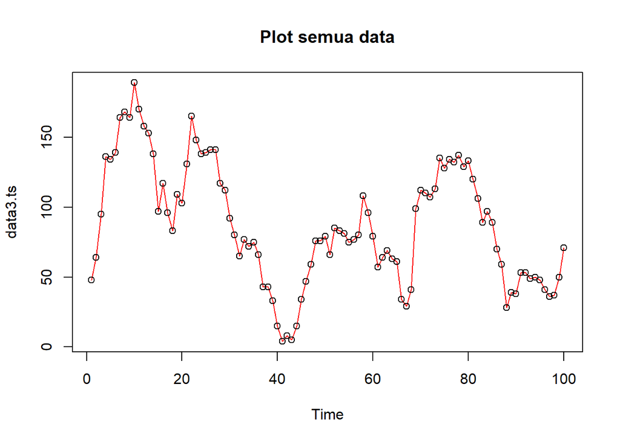

```r
#Membuat plot time series
plot(data3.ts, col="red",main="Plot semua data")
points(data3.ts)
```

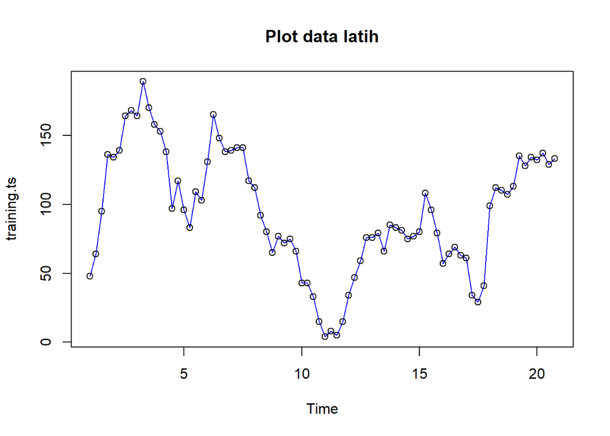

```r
plot(training.ts, col="blue",main="Plot data latih")
points(training.ts)
```

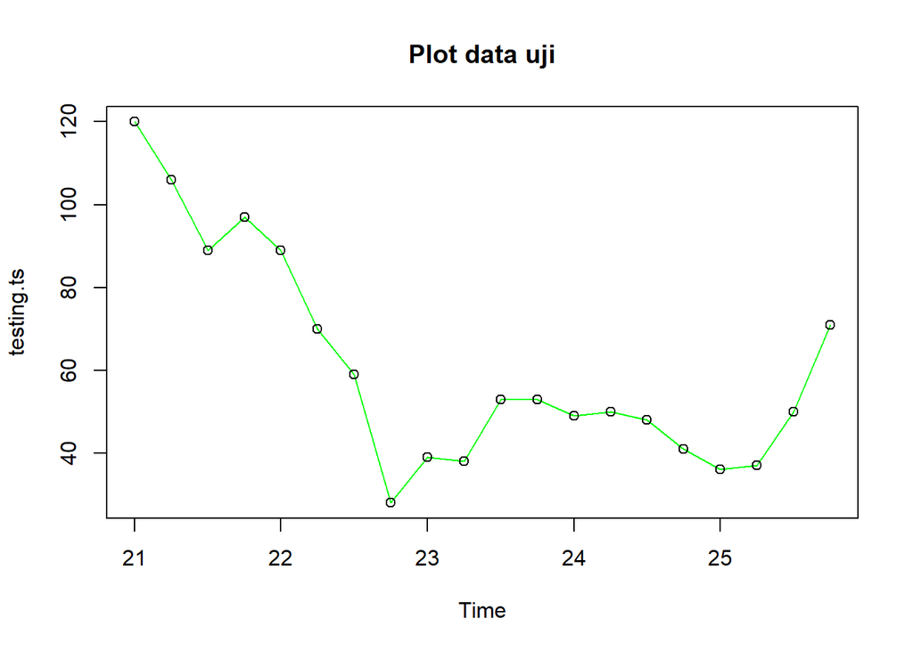

```r
plot(testing.ts, col="green",main="Plot data uji")
points(testing.ts)
```

Metode Holt-Winter untuk peramalan data musiman menggunakan tiga persamaan pemulusan yang terdiri atas persamaan untuk level $(L_t)$, trend $(B_t)$, dan komponen seasonal / musiman $(S_t)$ dengan parameter pemulusan berupa $\alpha$, $\beta$, dan $\gamma$. Metode Holt-Winter musiman terbagi menjadi dua, yaitu metode aditif dan metode multiplikatif. Perbedaan persamaan dan contoh datanya adalah sebagai berikut.

[figure not shown]

Pemulusan data musiman dengan metode Winter dilakukan menggunakan fungsi `HoltWinters()` dengan memasukkan argumen tambahan, yaitu `gamma()` dan `seasonal()` . Arguman `seasonal()` diinisialisasi menyesuaikan jenis musiman, aditif atau multiplikatif.

### Winter Aditif

Perhitungan dengan model aditif dilakukan jika plot data asli menunjukkan fluktuasi musiman yang relatif stabil (konstan).

#### Pemulusan

```r
#Pemulusan dengan winter aditif
winter1 <- HoltWinters(training.ts,alpha=0.2,beta=0.1,gamma=0.1,seasonal = "additive")
winter1$fitted
```

```
##             xhat     level       trend     season
##  2 Q1  95.337500  81.18750 17.02500000  -2.875000
##  2 Q2 113.243250 105.94500 17.79825000 -10.500000
##  2 Q3 143.457985 128.89460 18.31338500  -3.750000
##  2 Q4 187.165613 151.31639 18.72422530  17.125000
##  3 Q1 184.766404 166.20749 18.34091303   0.218000
##  3 Q2 189.881248 180.39512 17.92558496  -8.439460
##  3 Q3 213.945780 198.14446 17.90796000  -2.106639
##  3 Q4 239.884058 207.26326 17.02904441  15.591751
##  4 Q1 221.863546 207.91550 15.39136326  -1.443312
##  4 Q2 215.038282 209.53415 14.01409233  -8.509960
##  4 Q3 214.991611 208.14059 12.47332670  -5.622301
##  4 Q4 216.170111 197.01559 10.11349448   9.041026
##  5 Q1 188.472758 187.29506  8.13009227  -6.952396
##  5 Q2 168.538217 176.93060  6.28063710 -14.673022
```

[output cut: 62 more lines]

```r
xhat1 <- winter1$fitted[,2]

winter1.opt<- HoltWinters(training.ts, alpha= NULL,  beta = NULL, gamma = NULL, seasonal = "additive")
winter1.opt
```

```
## Holt-Winters exponential smoothing with trend and additive seasonal component.
##
## Call:
## HoltWinters(x = training.ts, alpha = NULL, beta = NULL, gamma = NULL,     seasonal = "additive")
##
## Smoothing parameters:
##  alpha: 0.8764455
##  beta : 0.1288954
##  gamma: 1
##
## Coefficients:
##          [,1]
## a  139.866341
## b    3.227256
## s1  -1.918213
## s2   1.057006
## s3  -7.362975
## s4  -6.866341
```

```r
winter1.opt$fitted
```

```
##             xhat      level       trend       season
##  2 Q1  95.337500  81.187500 17.02500000  -2.87500000
##  2 Q2 142.990769 132.098073 21.39269583 -10.50000000
##  2 Q3 167.184937 149.993078 20.94185937  -3.75000000
##  2 Q4 205.850571 168.143513 20.58205760  17.12500000
##  3 Q1 173.759622 155.551609 16.30608525   1.90192694
##  3 Q2 167.514383 163.303919 15.20354251 -10.99307757
##  3 Q3 210.825688 197.338432 17.63076884  -4.14351338
##  3 Q4 204.654801 179.187712 13.01869806  12.44839056
##  4 Q1 159.760216 151.316021  7.74811344   0.69608150
##  4 Q2 151.785154 153.139174  6.98441300  -8.33843235
##  4 Q3 144.281045 148.041651  5.42710652  -9.18771197
##  4 Q4 118.799253 112.029499  0.08577516   6.68397869
##  5 Q1 110.281667 110.538327 -0.11748614  -0.13917383
##  5 Q2  86.131204  97.903738 -1.73088357 -10.04165061
```

[output cut: 62 more lines]

```r
xhat1.opt <- winter1.opt$fitted[,2]
```

#### Peramalan

```r
#Forecast
forecast1 <- predict(winter1, n.ahead = 20)
forecast1.opt <- predict(winter1.opt, n.ahead = 20)
```

#### Plot Deret Waktu

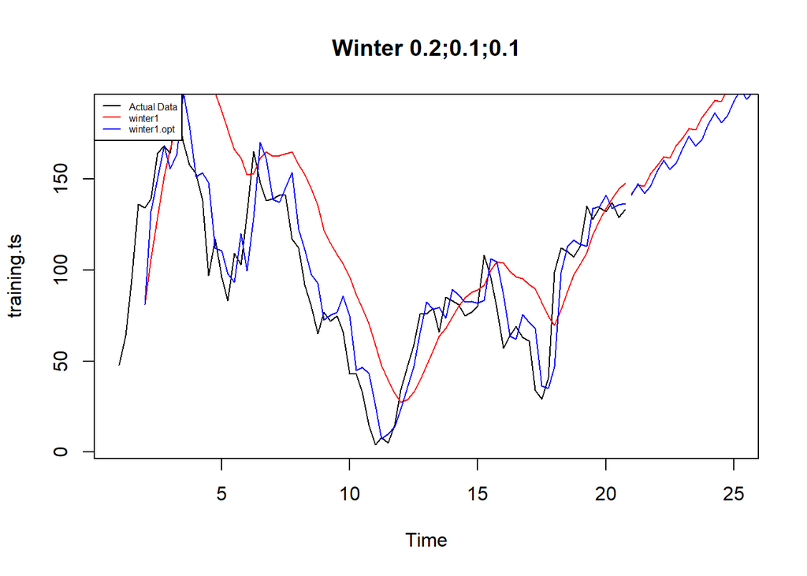

```r
#Plot time series
plot(training.ts,main="Winter 0.2;0.1;0.1",type="l",col="black",
     xlim=c(1,25),pch=12)
lines(xhat1,type="l",col="red")
lines(xhat1.opt,type="l",col="blue")
lines(forecast1,type="l",col="red")
lines(forecast1.opt,type="l",col="blue")
legend("topleft",c("Actual Data",expression(paste(winter1)),
                   expression(paste(winter1.opt))),cex=0.5,
       col=c("black","red","blue"),lty=1)
```

#### Akurasi Data Latih

```r
#Akurasi data training
SSE1<-winter1$SSE
MSE1<-winter1$SSE/length(training.ts)
RMSE1<-sqrt(MSE1)
akurasi1 <- matrix(c(SSE1,MSE1,RMSE1))
row.names(akurasi1)<- c("SSE", "MSE", "RMSE")
colnames(akurasi1) <- c("Akurasi")
akurasi1
```

```
##           Akurasi
## SSE  120791.90372
## MSE    1509.89880
## RMSE     38.85742
```

```r
SSE1.opt<-winter1.opt$SSE
MSE1.opt<-winter1.opt$SSE/length(training.ts)
RMSE1.opt<-sqrt(MSE1.opt)
akurasi1.opt <- matrix(c(SSE1.opt,MSE1.opt,RMSE1.opt))
row.names(akurasi1.opt)<- c("SSE1.opt", "MSE1.opt", "RMSE1.opt")
colnames(akurasi1.opt) <- c("Akurasi")
akurasi1.opt
```

```
##               Akurasi
## SSE1.opt  31345.70575
## MSE1.opt    391.82132
## RMSE1.opt    19.79448
```

```r
akurasi1.train = data.frame(Model_Winter = c("Winter 1","Winter1 optimal"),
                            Nilai_SSE=c(SSE1,SSE1.opt),
                            Nilai_MSE=c(MSE1,MSE1.opt),Nilai_RMSE=c(RMSE1,RMSE1.opt))
akurasi1.train
```

```
##      Model_Winter Nilai_SSE Nilai_MSE Nilai_RMSE
## 1        Winter 1 120791.90 1509.8988   38.85742
## 2 Winter1 optimal  31345.71  391.8213   19.79448
```

#### Akurasi Data Uji

```r
#Akurasi Data Testing
forecast1<-data.frame(forecast1)
testing.ts<-data.frame(testing.ts)
selisih1<-forecast1-testing.ts
SSEtesting1<-sum(selisih1^2)
MSEtesting1<-SSEtesting1/length(testing.ts)

forecast1.opt<-data.frame(forecast1.opt)
selisih1.opt<-forecast1.opt-testing.ts
SSEtesting1.opt<-sum(selisih1.opt^2)
MSEtesting1.opt<-SSEtesting1.opt/length(testing.ts)
```

```r
akurasi_testing <- data.frame(
  Model = c("Model1", "Model Optimum"),
  SSE   = c(SSEtesting1, SSEtesting1.opt),
  MSE   = c(MSEtesting1, MSEtesting1.opt)
)

akurasi_testing
```

```
##           Model      SSE      MSE
## 1        Model1 310705.8 310705.8
## 2 Model Optimum 269592.1 269592.1
```

### Winter Multiplikatif

Model multiplikatif digunakan cocok digunakan jika plot data asli menunjukkan fluktuasi musiman yang bervariasi.

#### Pemulusan

```r
#Pemulusan dengan winter multiplikatif
winter2 <- HoltWinters(training.ts,alpha=0.2,beta=0.1,gamma=0.3,seasonal = "multiplicative")
winter2$fitted
```

```
##             xhat     level      trend    season
##  2 Q1  95.607363  81.18750 17.0250000 0.9734745
##  2 Q2 114.399854 106.10025 17.8137754 0.9232195
##  2 Q3 142.101455 129.24324 18.3466962 0.9628126
##  2 Q4 194.956369 152.13880 18.8015832 1.1404933
##  3 Q1 195.673524 166.21324 18.3288690 1.0603191
##  3 Q2 190.194526 178.56778 17.7314352 0.9689011
##  3 Q3 213.194609 196.05264 17.7067778 0.9973577
##  3 Q4 244.480524 205.09761 16.8405970 1.1015703
##  4 Q1 225.438883 206.23689 15.2704652 1.0177490
##  4 Q2 213.919288 207.27223 13.8469534 0.9674388
##  4 Q3 206.122740 205.42428 12.2774632 0.9468125
##  4 Q4 204.814312 194.65120  9.9724084 1.0009320
##  5 Q1 182.380435 187.07710  8.2177574 0.9338722
##  5 Q2 160.953119 176.79544  6.3678162 0.8787413
```

[output cut: 62 more lines]

```r
xhat2 <- winter2$fitted[,2]

winter2.opt<- HoltWinters(training.ts, alpha= NULL,  beta = NULL, gamma = NULL, seasonal = "multiplicative")
winter2.opt$fitted
```

```
##              xhat      level      trend    season
##  2 Q1  95.6073634  81.187500 17.0250000 0.9734745
##  2 Q2 144.4708138 134.638339 21.8475310 0.9232195
##  2 Q3 165.7344321 151.012773 21.1229305 0.9628126
##  2 Q4 218.2614021 170.471901 20.9026545 1.1404933
##  3 Q1 165.3973316 150.671402 15.5138365 0.9952589
##  3 Q2 165.8936672 164.888509 15.3421583 0.9204519
##  3 Q3 213.4062922 203.416148 18.4117568 0.9620354
##  3 Q4 215.2527427 180.155568 12.8946256 1.1150092
##  4 Q1 151.4211228 145.625554  6.6159289 0.9946115
##  4 Q2 149.1417559 153.707642  6.8100383 0.9291298
##  4 Q3 146.0604425 149.442177  5.3437177 0.9436289
##  4 Q4 114.7390938 106.766527 -1.0137168 1.0849744
##  5 Q1 106.4263083 107.677449 -0.7589078 0.9953962
##  5 Q2  87.9150727  97.244214 -2.0397224 0.9234341
```

[output cut: 62 more lines]

```r
xhat2.opt <- winter2.opt$fitted[,2]
```

#### Peramalan

```r
#Forecast
forecast2 <- predict(winter2, n.ahead = 20)
forecast2.opt <- predict(winter2.opt, n.ahead = 20)
```

#### Plot Deret Waktu

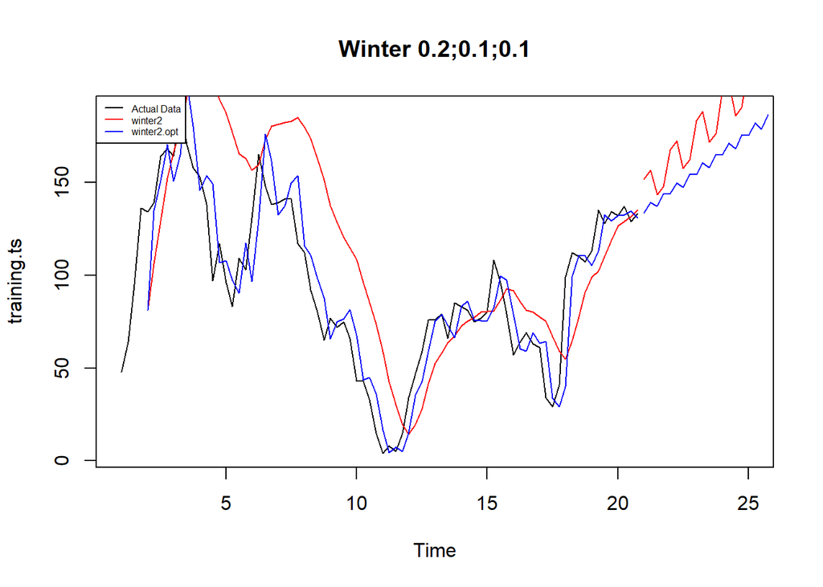

```r
#Plot time series
plot(training.ts,main="Winter 0.2;0.1;0.1",type="l",col="black",
     xlim=c(1,25),pch=12)
lines(xhat2,type="l",col="red")
lines(xhat2.opt,type="l",col="blue")
lines(forecast2,type="l",col="red")
lines(forecast2.opt,type="l",col="blue")
legend("topleft",c("Actual Data",expression(paste(winter2)),
                   expression(paste(winter2.opt))),cex=0.5,
       col=c("black","red","blue"),lty=1)
```

#### Akurasi Data Latih

```r
#Akurasi data training
SSE2<-winter2$SSE
MSE2<-winter2$SSE/length(training.ts)
RMSE2<-sqrt(MSE2)
akurasi1 <- matrix(c(SSE2,MSE2,RMSE2))
row.names(akurasi1)<- c("SSE2", "MSE2", "RMSE2")
colnames(akurasi1) <- c("Akurasi lamda=0.2")
akurasi1
```

```
##       Akurasi lamda=0.2
## SSE2       105462.15386
## MSE2         1318.27692
## RMSE2          36.30808
```

```r
SSE2.opt<-winter2.opt$SSE
MSE2.opt<-winter2.opt$SSE/length(training.ts)
RMSE2.opt<-sqrt(MSE2.opt)
akurasi1.opt <- matrix(c(SSE2.opt,MSE2.opt,RMSE2.opt))
row.names(akurasi1.opt)<- c("SSE2.opt", "MSE2.opt", "RMSE2.opt")
colnames(akurasi1.opt) <- c("Akurasi")
akurasi1.opt
```

```
##              Akurasi
## SSE2.opt  33775.9707
## MSE2.opt    422.1996
## RMSE2.opt    20.5475
```

```r
akurasi2.train = data.frame(Model_Winter = c("Winter 1","winter2 optimal"),
                            Nilai_SSE=c(SSE2,SSE2.opt),
                            Nilai_MSE=c(MSE2,MSE2.opt),Nilai_RMSE=c(RMSE2,RMSE2.opt))
akurasi2.train
```

```
##      Model_Winter Nilai_SSE Nilai_MSE Nilai_RMSE
## 1        Winter 1 105462.15 1318.2769   36.30808
## 2 winter2 optimal  33775.97  422.1996   20.54750
```

#### Akurasi Data Uji

```r
#Akurasi Data Testing
forecast2<-data.frame(forecast2)
testing.ts<-data.frame(testing.ts)
selisih2<-forecast2-testing.ts
SSEtesting2<-sum(selisih2^2)
MSEtesting2<-SSEtesting2/length(testing.ts)

forecast2.opt<-data.frame(forecast2.opt)
selisih2.opt<-forecast2.opt-testing.ts
SSEtesting2.opt<-sum(selisih2.opt^2)
MSEtesting2.opt<-SSEtesting2.opt/length(testing.ts)
```

```r
# Atau rapikan dalam tabel
akurasi_testing2 <- data.frame(
  Model = c("Model2", "Model2 Optimal"),
  SSE   = c(SSEtesting2, SSEtesting2.opt),
  MSE   = c(MSEtesting2, MSEtesting2.opt)
)

akurasi_testing2
```

```
##            Model      SSE      MSE
## 1         Model2 319165.3 319165.3
## 2 Model2 Optimal 221700.5 221700.5
```

## Tugas

1. Setiap kelompok memilih satu data time series dengan panjang ≥ 500 periode.
2. Data dibagi rata ke setiap anggota; minimal 100 observasi per orang.
3. Terapkan metode pemulusan yang sudah dipelajari (SMA, DMA, SES, DES, atau Holt-Winters) pada bagian data masing-masing
4. Bandingkan kinerja metode dan tentukan metode terbaik untuk data tersebut menggunakan metrik akurasi (mis. SSE/MSE/RMSE/MAPE), lalu jelaskan alasannya secara singkat.

   Upload tugas per individu ke GitHub pada folder `Pertemuan-2` dengan format HTML bernama `Tugas-Pertemuan-2.html`.
5. Deadline Pengumpulan : **Senin, Jam 23.59 WIB**